# From clinics to sewers: leveraging environmental surveillance and whole genome sequencing to inform transmission of ESBL-*Escherichia coli* in Switzerland

## 6.6 Plot Figure 4

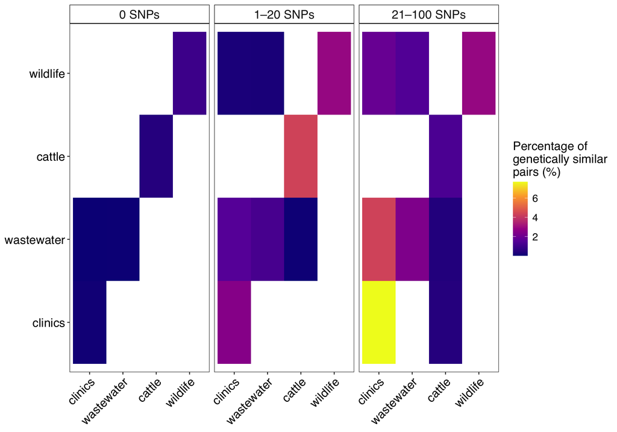

Fig. 4: Percentage of genetically similar ESBL-*Escherichia coli* isolate pairs within and between compartments across SNPs thresholds. Diagonal cells represent within-compartment percentages; off-diagonal cells represent between-compartment percentages. White tiles indicate unobserved or zero values.

```r
# Prepare diagonal from within_props
within_diag <- within_props %>%
  transmute(
    Compartment1 = Compartment,
    Compartment2 = Compartment,
    SNP_Threshold,
    Percentage
  )

# Combine with between_props
all_compartments <- c("clinics", "wastewater", "cattle", "wildlife")
all_thresholds <- c("0 SNPs", "1–20 SNPs", "21–100 SNPs")
combined_heatmap_data <- bind_rows(between_props, within_diag) %>%
  mutate(
    Compartment1 = factor(Compartment1, levels = all_compartments),
    Compartment2 = factor(Compartment2, levels = all_compartments),
    SNP_Threshold = factor(SNP_Threshold, levels = all_thresholds)
  )

# Create full grid (to show white tiles for missing combinations)
full_grid <- expand.grid(
  Compartment1 = all_compartments,
  Compartment2 = all_compartments,
  SNP_Threshold = all_thresholds,
  stringsAsFactors = FALSE
)

combined_heatmap_data_complete <- full_grid %>%
  left_join(combined_heatmap_data, by = c("Compartment1", "Compartment2", "SNP_Threshold")) %>%
  mutate(
    Compartment1 = factor(Compartment1, levels = all_compartments),
    Compartment2 = factor(Compartment2, levels = all_compartments),
    SNP_Threshold = factor(SNP_Threshold, levels = all_thresholds)
  )

# Plot single heatmap with diagonal filled
figure4 <- ggplot(combined_heatmap_data_complete, aes(x = Compartment1, y = Compartment2, fill = Percentage)) +
  geom_tile() +
  facet_wrap(~ SNP_Threshold) + scale_fill_viridis_c(option = "C", na.value = "white")+
  labs(fill = "Percentage of\ngenetically similar\npairs (%)") +
  theme_bw() +
  theme(
    text = element_text(family = "sans"),
    panel.grid = element_blank(),
    strip.text = element_text(size = 14),
    axis.text.x = element_text(color = "black", size = 14, angle = 45, hjust = 1),
    axis.text.y = element_text(color = "black", size = 14),
    strip.background = element_rect(fill = "white", color = "black"),
    axis.title.x = element_blank(),
    axis.title.y = element_blank(),
    legend.text = element_text(size = 12),
    legend.title = element_text(size = 14),
  )

# Save Figure 4
#ggsave("./figures/Figure4.pdf", plot = figure4, device = cairo_pdf, width = 11.69, height = 8.27)

# Display plot
print(figure4)
```

# 7. Transition analysis

This section presents the complete workflow for ancestral state reconstruction and transition analysis of 762 ESBL-producing *Escherichia coli* isolates collected in Switzerland from four sources: cattle, wildlife, clinical settings, and wastewater. The analysis uses maximum parsimony applied to phylogenetic trees to infer ancestral origins and quantify directional transitions between sources. Observed transitions are then compared to randomized null models to assess whether any directional patterns deviate from expectation.

The notebook is structured as follows:

- Reproduction of all figures based on pre-generated results for immediate viewing.
- Ancestral state reconstruction and transition analysis on the consensus phylogenetic tree.
- Bootstrap-based transition analysis using 1000 bootstrap trees to account for phylogenetic uncertainty.
- ST-specific transition analysis for dominant sequence types (ST131, ST10, ST38, ST69, ST1193), using the same bootstrap framework.

Note: Pre-generated data are loaded at the start for rapid reproduction of outputs. All steps can be fully re-executed in later sections to regenerate or update results.

## 7.1 Reproduce figures

This section loads previously computed outputs and uses them to recreate the main plots, without recomputing any randomizations or reconstructions. For full reproducibility, see Section 7.4, 7.5, and 7.6.

### 7.1.1 Load pre-generated data

```r
# Full tree - bootstrap analysis
combined_results <- read.csv("parsimony/bootstrap_MP_significance_results.csv")
all_random_counts <- readRDS("parsimony/all_random_counts.rds")
significance_summary <- read.csv("parsimony/significance_summary_across_trees.csv")

# ST-specific tree - bootstrap analysis
combined_results_st131 <- read.csv("parsimony/bootstrap_MP_significance_results_st131.csv")
all_random_counts_st131 <- readRDS("parsimony/all_random_counts_st131.rds")
significance_summary_st131 <- read.csv("parsimony/significance_summary_across_trees_ST131.csv")

combined_results_st10 <- read.csv("parsimony/bootstrap_MP_significance_results_st10.csv")
all_random_counts_st10 <- readRDS("parsimony/all_random_counts_st10.rds")
significance_summary_st10 <- read.csv("parsimony/significance_summary_across_trees_ST10.csv")

combined_results_st38 <- read.csv("parsimony/bootstrap_MP_significance_results_st38.csv")
all_random_counts_st38 <- readRDS("parsimony/all_random_counts_st38.rds")
significance_summary_st38 <- read.csv("parsimony/significance_summary_across_trees_ST38.csv")

combined_results_st69 <- read.csv("parsimony/bootstrap_MP_significance_results_st69.csv")
all_random_counts_st69 <- readRDS("parsimony/all_random_counts_st69.rds")
significance_summary_st69 <- read.csv("parsimony/significance_summary_across_trees_ST69.csv")

combined_results_st1193 <- read.csv("parsimony/bootstrap_MP_significance_results_st1193.csv")
all_random_counts_st1193 <- readRDS("parsimony/all_random_counts_st1193.rds")
significance_summary_st1193 <- read.csv("parsimony/significance_summary_across_trees_ST1193.csv")

# Consensus tree data
all_transitions <- readRDS("parsimony/randomization_consensus.rds")
transitions_observed <- read.csv("parsimony/counted_consensus.csv")

# Wastewater and clinical isolates tree - bootstrap analysis
combined_results_wwc <- read.csv("parsimony/bootstrap_MP_significance_results_wwc.csv")
all_random_counts_wwc <- readRDS("parsimony/all_random_counts_wwc.rds")
significance_summary_wwc <- read.csv("parsimony/significance_summary_across_trees_wwc.csv")

#ST-specific wastewater and clinical isolates only - bootstrap analysis
combined_results_wwc_st131 <- read.csv("parsimony/bootstrap_MP_significance_results_WWC_ST131.csv")
combined_results_wwc_st10  <- read.csv("parsimony/bootstrap_MP_significance_results_WWC_ST10.csv")
combined_results_wwc_st38  <- read.csv("parsimony/bootstrap_MP_significance_results_WWC_ST38.csv")
combined_results_wwc_st69  <- read.csv("parsimony/bootstrap_MP_significance_results_WWC_ST69.csv")
combined_results_wwc_st1193 <- read.csv("parsimony/bootstrap_MP_significance_results_WWC_ST1193.csv")

all_random_counts_wwc_st131 <- readRDS("parsimony/all_random_counts_WWC_ST131.rds")
all_random_counts_wwc_st10  <- readRDS("parsimony/all_random_counts_WWC_ST10.rds")
all_random_counts_wwc_st38  <- readRDS("parsimony/all_random_counts_WWC_ST38.rds")
all_random_counts_wwc_st69  <- readRDS("parsimony/all_random_counts_WWC_ST69.rds")
all_random_counts_wwc_st1193 <- readRDS("parsimony/all_random_counts_WWC_ST1193.rds")

significance_summary_wwc_st131 <- read.csv("parsimony/significance_summary_across_trees_WWC_ST131.csv")
significance_summary_wwc_st10  <- read.csv("parsimony/significance_summary_across_trees_WWC_ST10.csv")
significance_summary_wwc_st38  <- read.csv("parsimony/significance_summary_across_trees_WWC_ST38.csv")
significance_summary_wwc_st69  <- read.csv("parsimony/significance_summary_across_trees_WWC_ST69.csv")
significance_summary_wwc_st1193 <- read.csv("parsimony/significance_summary_across_trees_WWC_ST1193.csv")
```

### 7.1.2 Format pre-generated data

This section prepares the Z-score matrices used to assess how far each observed transition count deviates from its null distribution, computed across bootstrap trees. These values allow us to quantify whether a given transition occurs more or less frequently than expected by chance.

We apply a helper function `compute_z_scores()` to: *i)* Filter out transitions that were never observed, *ii)* Compute Z-scores per transition and per tree, *iii)* Return a unified data frame with `Transition`, `Z_score`, and `Tree` .

```r
# Helper function to compute z-scores from observed and randomized transition data
compute_z_scores <- function(combined_results, all_random_counts) {
  nonzero_transitions <- combined_results %>%
    group_by(Transition) %>%
    summarise(sum_obs = sum(Observed)) %>%
    filter(sum_obs > 0) %>%
    pull(Transition)

  combined_results <- combined_results %>%
    filter(Transition %in% nonzero_transitions)

  transition_labels <- nonzero_transitions

  z_scores <- lapply(seq_along(all_random_counts), function(i) {
    tree_name <- paste0("Tree_", i)
    null_matrix <- all_random_counts[[tree_name]][, transition_labels, drop = FALSE]

    rand_mean <- colMeans(null_matrix)
    rand_sd <- apply(null_matrix, 2, sd)

    observed_df <- combined_results %>%
      filter(Tree == tree_name, Transition %in% transition_labels) %>%
      arrange(match(Transition, transition_labels)) %>%
      pull(Observed)

    data.frame(
      Tree = tree_name,
      Transition = transition_labels,
      Z_score = (observed_df - rand_mean) / rand_sd
    )
  }) %>% bind_rows()

  z_scores$Transition <- gsub("_to_", " to ", z_scores$Transition)
  return(z_scores)
}
```

We apply the function to each dataset:

```r
z_scores        <- compute_z_scores(combined_results, all_random_counts)
z_scores_st131  <- compute_z_scores(combined_results_st131, all_random_counts_st131)
z_scores_st10   <- compute_z_scores(combined_results_st10, all_random_counts_st10)
z_scores_st38   <- compute_z_scores(combined_results_st38, all_random_counts_st38)
z_scores_st69   <- compute_z_scores(combined_results_st69, all_random_counts_st69)
z_scores_st1193 <- compute_z_scores(combined_results_st1193, all_random_counts_st1193)
z_scores_wwc        <- compute_z_scores(combined_results_wwc, all_random_counts_wwc)
z_scores_wwc_st131 <- compute_z_scores(combined_results_wwc_st131, all_random_counts_wwc_st131)
z_scores_wwc_st10  <- compute_z_scores(combined_results_wwc_st10,  all_random_counts_wwc_st10)
z_scores_wwc_st38  <- compute_z_scores(combined_results_wwc_st38,  all_random_counts_wwc_st38)
z_scores_wwc_st69  <- compute_z_scores(combined_results_wwc_st69,  all_random_counts_wwc_st69)
z_scores_wwc_st1193 <- compute_z_scores(combined_results_wwc_st1193, all_random_counts_wwc_st1193)

# Load consensus tree observed transition matrix for histogram plots
observed_vector <- as.vector(as.matrix(transitions_observed))
```

### 7.1.3 Plot Figure 5

This chunk creates a multi-panel boxplot showing the Z-score distributions of transition frequencies for the full tree and ST-specific subsets. Each box represents the distribution across 1000 bootstrap trees. The ±1.96 lines represent the 95% confidence interval threshold.

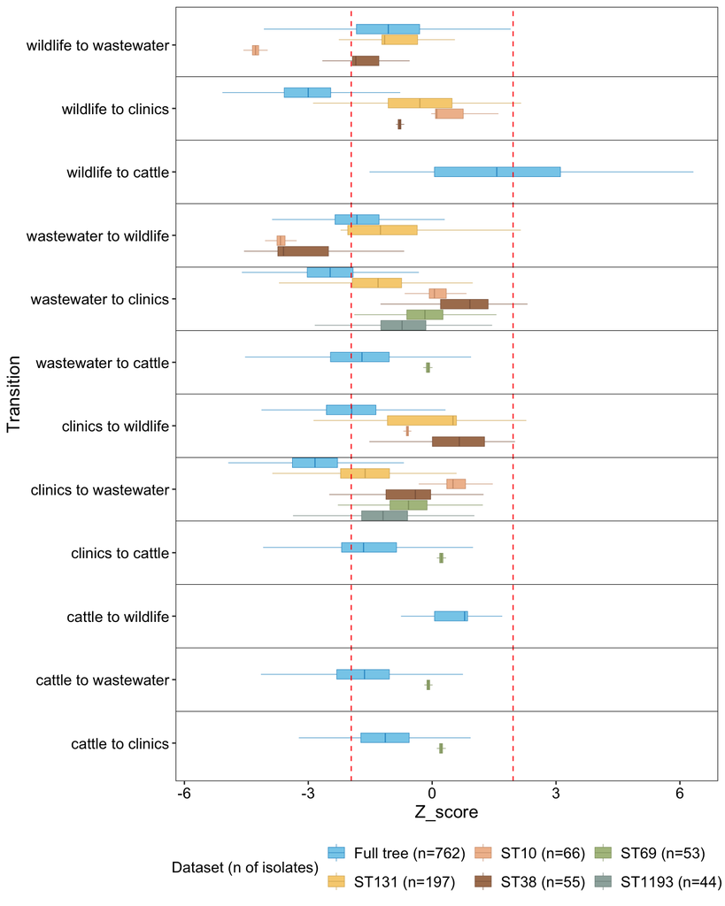

Fig. 5: Z-score distributions of collection source transitions across 1,000 bootstrap phylogenies for the full dataset and dominant sequence types (STs). Transitions between collection sources (clinics, wastewater, wildlife, cattle) were inferred using maximum parsimony ancestral state reconstruction across 1,000 bootstrap phylogenetic trees. For each tree, tip states were randomized 1,000 times (preserving source frequencies) to generate a null distribution of transition counts. Z-scores represent standardized deviations of observed transitions relative to the null. Each boxplot shows Z-score distributions per transition type, stratified by dataset subset (full dataset and the five dominant STs: ST131, ST10, ST38, ST69, ST1193). The legend shows the number of isolates retained in the analysis for each ST. Red dashed lines indicate ±1.96, corresponding to the 95% confidence interval under the null model. Transitions were reconstructed using the acctran and ancestral.pars functions from the ape package (v5.7.1) in R (v4.1.2). Positive Z-scores indicate transitions occurring more frequently than expected by chance; negative Z-scores indicate less frequent transitions.

```r
# Add group labels
z_scores$Group <- "Full tree"
z_scores_st131$Group <- "ST131"
z_scores_st10$Group <- "ST10"
z_scores_st38$Group <- "ST38"
z_scores_st69$Group <- "ST69"
z_scores_st1193$Group <- "ST1193"

# Combine data
z_scores_combined <- bind_rows(z_scores, z_scores_st131, z_scores_st10, z_scores_st38, z_scores_st69, z_scores_st1193)

# Rename "livestock" to "cattle" in transition labels before formatting
z_scores_combined$Transition <- gsub("livestock", "cattle", z_scores_combined$Transition)

# Clean up and format transition labels
z_scores_combined$Transition <- gsub("_to_", " → ", z_scores_combined$Transition)

# Ensure transitions and group order
z_scores_combined$Transition <- factor(z_scores_combined$Transition,
                                       levels = rev(sort(unique(z_scores_combined$Transition))))
z_scores_combined$Group <- factor(z_scores_combined$Group, levels = c("ST1193", "ST69", "ST38", "ST10","ST131", "Full tree"))

# Ensure every combination is represented
z_scores_combined_full <- expand.grid(
  Transition = unique(z_scores_combined$Transition),
  Group = levels(z_scores_combined$Group)
) %>%
  left_join(z_scores_combined, by = c("Transition", "Group"))

# Order transitions and group
z_scores_combined_full$Transition <- factor(z_scores_combined_full$Transition,
                                            levels = rev(sort(unique(z_scores_combined_full$Transition))))
z_scores_combined_full$Group <- factor(z_scores_combined_full$Group,
                                       levels = c("ST1193","ST69","ST38", "ST10", "ST131", "Full tree"))

# Get unique levels of transitions
trans_levels <- levels(z_scores_combined_full$Transition)

# Determine where to place lines (between factors, i.e., at integer positions)
vline_positions <- seq(1.5, length(trans_levels) - 0.5, by = 1)

# Plot
figure5 = ggplot(z_scores_combined_full, aes(x = Transition, y = Z_score, fill = Group, color = Group)) +
  geom_boxplot(position = position_dodge2(preserve = "single", padding = 0.1),
               outlier.shape = NA, width = 1, linewidth = 0.2) +
  geom_hline(yintercept = c(-1.96, 1.96), linetype = "dashed", color = "red", linewidth = 0.4) +
  coord_flip() +
  scale_fill_manual(
    values = c("Full tree" = "skyblue", "ST131" = "#f7d080", "ST10" = "#f0bd9bff",
               "ST38" = "#ab7d5dff", "ST69" = "#afbf8dff", "ST1193" = "#9cafaaff"),
    labels = c("Full tree" = "Full tree (n=762)",
               "ST131" = "ST131 (n=197)",
               "ST10" = "ST10 (n=66)",
               "ST38" = "ST38 (n=55)",
               "ST69" = "ST69 (n=53)",
               "ST1193" = "ST1193 (n=44)")
  ) +
  scale_color_manual(
    values = c("Full tree" = "#3399cc", "ST131" = "#d6b060", "ST10" = "#d09b79",
               "ST38" = "#8c6249", "ST69" = "#8e9e6d", "ST1193" = "#7c8e8a"),
    labels = c("Full tree" = "Full tree (n=762)",
               "ST131" = "ST131 (n=197)",
               "ST10" = "ST10 (n=66)",
               "ST38" = "ST38 (n=55)",
               "ST69" = "ST69 (n=53)",
               "ST1193" = "ST1193 (n=44)")
  ) +
  guides(
    fill = guide_legend(title = "Dataset (n of isolates)", reverse = TRUE),
    color = guide_legend(title = "Dataset (n of isolates)", reverse = TRUE)
  ) +
  theme_bw() +
  theme(
    axis.text.y = element_text(size = 12, color = "black"),
    axis.text.x = element_text(size = 12, color = "black"),
    axis.title = element_text(size = 14, color = "black"),
    legend.position = "bottom",
    legend.justification = "center",
    legend.box = "horizontal",
    legend.text = element_text(size = 12, color = "black"),
    legend.title = element_text(size = 12, color = "black"),
    panel.grid.major = element_blank(),
    panel.grid.minor = element_blank()
  ) +
  geom_vline(xintercept = vline_positions, linetype = "solid", color = "black", size = 0.2)

# Print the plot to the notebook
print(figure5)
```

```r
# Save as PDF in A4 portrait format
#ggsave("figures/Figure5.pdf", plot = figure5, width = 8.27, height = 11.69, units = "in")
```

This chunk visualizes the null distributions of transitions from the consensus tree randomization. Histograms show how often each transition count occurred under 1000 random permutations, with red and dashed black lines marking the observed count and 95% confidence intervals, respectively.

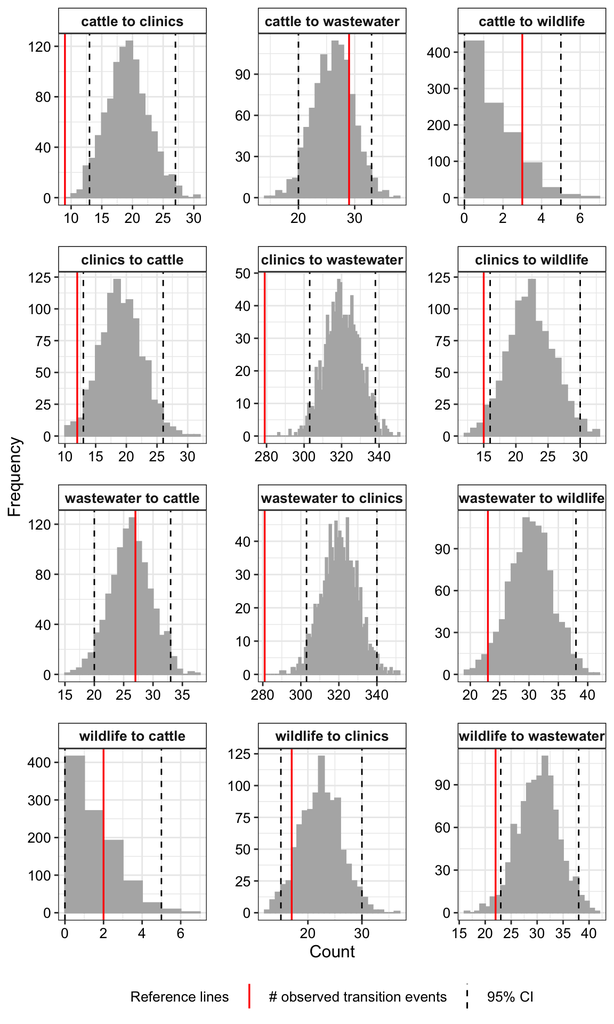

Fig. S4: Distribution of observed and randomized transition counts on the consensus phylogeny. Transitions between collection sources (clinics, wastewater, wildlife, cattle) were inferred using maximum parsimony ancestral state reconstruction on the consensus maximum likelihood phylogenetic tree of 762 isolates. For each transition type, tip states were randomized 1,000 times (preserving source frequencies) to generate null distributions of transition counts. Each facet shows the distribution of transition counts from the null model (histogram) for a specific transition type. Solid red lines indicate the observed number of transitions; dashed black lines mark the central 95% confidence interval from the null model. Transitions were reconstructed using the acctran and ancestral.pars functions from the ape package (v5.7.1) in R (v4.1.2).

```r
# Convert randomizations to long format
transitions_long <- as.data.frame(all_transitions) %>%
  mutate(Replicate = 1:nrow(.)) %>%
  pivot_longer(cols = -Replicate, names_to = "Transition", values_to = "Count")

# Prepare observed data and 95% CI
ci_data <- apply(all_transitions, 2, quantile, probs = c(0.025, 0.975))
ci_df <- data.frame(
  Transition = colnames(all_transitions),
  CI_Lower = ci_data[1, ],
  CI_Upper = ci_data[2, ],
  Original_Count = as.vector(observed_vector)
)

# Exclude self-transitions
exclude_self <- c("clinics_to_clinics", "cattle_to_cattle",
                  "wastewater_to_wastewater", "wildlife_to_wildlife")

transitions_long <- filter(transitions_long, !Transition %in% exclude_self)
ci_df <- filter(ci_df, !Transition %in% exclude_self)

# Prettify transition labels
transitions_long$Transition <- gsub("_", " ", transitions_long$Transition)
ci_df$Transition <- gsub("_", " ", ci_df$Transition)

# Plot
FigureS4 = ggplot(transitions_long, aes(x = Count)) +
  geom_histogram(binwidth = 1, fill = "gray70", color = "gray70", boundary = 1) +
  geom_vline(data = ci_df, aes(xintercept = CI_Lower, linetype = "95% CI"), color = "black", linewidth = 0.5) +
  geom_vline(data = ci_df, aes(xintercept = CI_Upper, linetype = "95% CI"), color = "black", linewidth = 0.5) +
  geom_vline(data = ci_df, aes(xintercept = Original_Count, linetype = "# observed transition events"), color = "red", linewidth = 0.6) +
  scale_linetype_manual(values = c("95% CI" = "dashed", "# observed transition events" = "solid")) +
  labs(x = "Count", y = "Frequency") +
  facet_wrap(~ Transition, scales = "free", ncol = 3) +
  theme_bw() +
  theme(
    strip.text = element_text(size = 10, face = "bold"),
    strip.background = element_rect(fill = "white", color = "black"),
    legend.position = "bottom",
    legend.direction = "horizontal",
    legend.text = element_text(size = 10, color = "black"),
    legend.title = element_text(size = 10, color = "black"),
    axis.title = element_text(size = 12),
    axis.text = element_text(size = 10, color = "black"),
    panel.spacing = unit(1, "lines")
  ) +
  guides(linetype = guide_legend(
    title = "Reference lines",
    override.aes = list(color = c("red", "black"))))

# Print the plot to the notebook
print(FigureS4)
```

```r
# Save as PDF in A4 portrait format
#ggsave("figures/FigureS4.pdf", plot = FigureS4, width = 8.27, height = 11.69, units = "in")
```

### 7.1.5 Plot Fig. S5

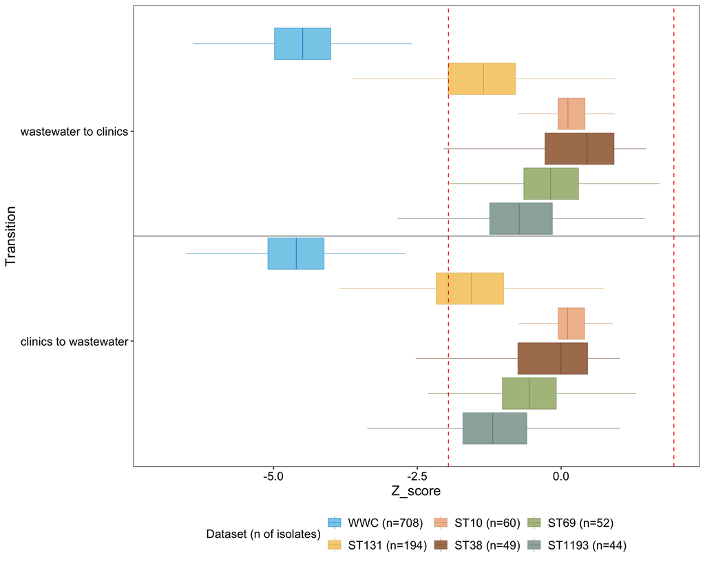

Fig. S5: Z-score distributions of collection source transitions across 1,000 bootstrap phylogenies for wastewater and clinical isolates (WWC). Transitions between collection sources (clinics, wastewater) were inferred using maximum parsimony ancestral state reconstruction across 1,000 bootstrap phylogenetic trees, considering only isolates from wastewater and clinical sources. For each tree, tip states were randomized 1,000 times (preserving source frequencies) to generate a null distribution of transition counts. Z-scores represent standardized deviations of observed transitions relative to the null. Each boxplot shows Z-score distributions per transition type, stratified by dataset subset (WWC-only full dataset and the five dominant sequence types: ST131, ST10, ST38, ST69, ST1193, all restricted to WWC isolates). The legend indicates the number of isolates retained in each subset. Red dashed lines mark ±1.96, corresponding to the 95% confidence interval under the null model. Transitions were reconstructed using the acctran and ancestral.pars functions from the ape package (v5.7.1) in R (v4.1.2). Positive Z-scores indicate transitions occurring more frequently than expected by chance; negative Z-scores indicate less frequent transitions.

```r
# Add group labels
z_scores_wwc$Group <- "Wastewater and clinical isolates"
z_scores_wwc_st131$Group <- "ST131"
z_scores_wwc_st10$Group <- "ST10"
z_scores_wwc_st38$Group <- "ST38"
z_scores_wwc_st69$Group <- "ST69"
z_scores_wwc_st1193$Group <- "ST1193"

# Combine data
z_scores_combined_wwc <- bind_rows(z_scores_wwc, z_scores_wwc_st131, z_scores_wwc_st10, z_scores_wwc_st38, z_scores_wwc_st69, z_scores_wwc_st1193)

# Rename "livestock" to "cattle" in transition labels before formatting
z_scores_combined_wwc$Transition <- gsub("livestock", "cattle", z_scores_combined_wwc$Transition)

# Clean up and format transition labels
z_scores_combined_wwc$Transition <- gsub("_to_", " → ", z_scores_combined_wwc$Transition)

# Ensure transitions and group order
z_scores_combined_wwc$Transition <- factor(z_scores_combined_wwc$Transition,
                                       levels = rev(sort(unique(z_scores_combined_wwc$Transition))))
z_scores_combined_wwc$Group <- factor(z_scores_combined_wwc$Group, levels = c("ST1193", "ST69", "ST38", "ST10","ST131", "Wastewater and clinical isolates"))

# Ensure every combination is represented
z_scores_combined_full_wwc <- expand.grid(
  Transition = unique(z_scores_combined_wwc$Transition),
  Group = levels(z_scores_combined_wwc$Group)
) %>%
  left_join(z_scores_combined_wwc, by = c("Transition", "Group"))


# Order transitions and group
z_scores_combined_full_wwc$Transition <- factor(z_scores_combined_full_wwc$Transition,
                                            levels = rev(sort(unique(z_scores_combined_full_wwc$Transition))))
z_scores_combined_full_wwc$Group <- factor(z_scores_combined_full_wwc$Group,
                                       levels = c("ST1193","ST69","ST38", "ST10", "ST131", "Wastewater and clinical isolates"))

# Get unique levels of transitions
trans_levels <- levels(z_scores_combined_full_wwc$Transition)

# Determine where to place lines (between factors, i.e., at integer positions)
vline_positions <- seq(1.5, length(trans_levels) - 0.5, by = 1)

# Plot
FigureS5 = ggplot(z_scores_combined_full_wwc, aes(x = Transition, y = Z_score, fill = Group, color = Group)) +
  geom_boxplot(position = position_dodge2(preserve = "single", padding = 0.1),
               outlier.shape = NA, width = 1, linewidth = 0.2) +
  geom_hline(yintercept = c(-1.96, 1.96), linetype = "dashed", color = "red", linewidth = 0.4) +
  coord_flip() +
  scale_fill_manual(
    values = c("Wastewater and clinical isolates" = "skyblue", "ST131" = "#f7d080", "ST10" = "#f0bd9bff",
               "ST38" = "#ab7d5dff", "ST69" = "#afbf8dff", "ST1193" = "#9cafaaff"),
    labels = c("Wastewater and clinical isolates" = "WWC (n=708)",
               "ST131" = "ST131 (n=194)",
               "ST10" = "ST10 (n=60)",
               "ST38" = "ST38 (n=49)",
               "ST69" = "ST69 (n=52)",
               "ST1193" = "ST1193 (n=44)")
  ) +
  scale_color_manual(
    values = c("Wastewater and clinical isolates" = "#3399cc", "ST131" = "#d6b060", "ST10" = "#d09b79",
               "ST38" = "#8c6249", "ST69" = "#8e9e6d", "ST1193" = "#7c8e8a"),
    labels = c("Wastewater and clinical isolates" = "WWC (n=708)",
               "ST131" = "ST131 (n=194)",
               "ST10" = "ST10 (n=60)",
               "ST38" = "ST38 (n=49)",
               "ST69" = "ST69 (n=52)",
               "ST1193" = "ST1193 (n=44)")
  ) +
  guides(
    fill = guide_legend(title = "Dataset (n of isolates)", reverse = TRUE),
    color = guide_legend(title = "Dataset (n of isolates)", reverse = TRUE)
  ) +
  theme_bw() +
  theme(
    axis.text.y = element_text(size = 12, color = "black"),
    axis.text.x = element_text(size = 12, color = "black"),
    axis.title = element_text(size = 14, color = "black"),
    legend.position = "bottom",
    legend.justification = "center",
    legend.box = "horizontal",
    legend.text = element_text(size = 12, color = "black"),
    legend.title = element_text(size = 12, color = "black"),
    panel.grid.major = element_blank(),
    panel.grid.minor = element_blank()
  ) +
  geom_vline(xintercept = vline_positions, linetype = "solid", color = "black", size = 0.2)

# Print the plot to the notebook
print(FigureS5)
```

```r
# Save as PDF in A4 portrait format
ggsave("figures/ExtendedDataFig3.pdf", plot = FigureS5, width = 11.69, height = 8.27, units = "in")
```

## 7.2 Consensus tree analysis

This section documents the complete re-execution of the ancestral state reconstruction and transition analysis on the consensus phylogeny and on the 1000 bootstrap trees using maximum parsimony. It includes:

- Loading trees and metadata
- Inferring ancestral source states
- Counting transitions between sources
- Generating randomized null models for comparison
- Assessing the statistical significance of observed transitions

### 7.2.1 Load tree and metadata

```r
# Load required data
tree <- read.tree("tree.treefile")
metadata <- read.csv("sample_annotations.csv", header =TRUE)

# Drop outgroup from the consensus tree
tree <- drop.tip(tree, "Escherichia_albertii")

# Filter metadata for tips present in the tree
tip_states <- metadata[metadata$Sample_ID %in% tree$tip.label, ]

# Create named vector of states
states <- tip_states$Source
names(states) <- tip_states$Sample_ID
states <- states[tree$tip.label]
```

### 7.2.2 Define transition counting function

This helper function counts source transitions along the tree based on inferred ancestral states.

```r
count_transitions_parsimony <- function(tree, tip_states, anc_states_names) {
  state_levels <- levels(tip_states)
  transitions <- matrix(0, nrow = length(state_levels), ncol = length(state_levels),
                        dimnames = list(state_levels, state_levels))
  for (i in 1:nrow(tree$edge)) {
    parent <- tree$edge[i, 1]
    child <- tree$edge[i, 2]

    parent_state <- if (parent <= length(tree$tip.label)) {
      tip_states[tree$tip.label[parent]]
    } else {
      anc_states_names[parent - length(tree$tip.label)]
    }

    child_state <- if (child <= length(tree$tip.label)) {
      tip_states[tree$tip.label[child]]
    } else {
      anc_states_names[child - length(tree$tip.label)]
    }

    if (!is.na(parent_state) && !is.na(child_state) && parent_state != child_state) {
      transitions[parent_state, child_state] <- transitions[parent_state, child_state] + 1
    }
  }
  return(transitions)
}
```

### 7.2.3 Ancestral state reconstruction

Observed tip states are mapped to a `phyDat` object and reconstructed using the ACCTRAN parsimony method.

```r
# Prepare tip states
states <- tip_states$Source
names(states) <- tip_states$Sample_ID
states <- states[tree$tip.label]  # Reorder to match the tree tips

# Stop if there are missing values
if (any(is.na(states))) stop("Missing state values detected!")

# Convert to factor and to list for phyDat
states <- factor(states, levels = c("clinics", "cattle", "wastewater", "wildlife"))
states_list <- as.list(as.character(states))
names(states_list) <- tree$tip.label

# Create the phyDat object
char_data <- phyDat(states_list, type = "USER", levels = levels(states))

# Perform parsimony reconstruction
fit_pars <- acctran(tree, char_data)
anc_states <- ancestral.pars(fit_pars, char_data)
```

```
## Node labels are not unique, used makeNodeLabel(tree, ...) to create them!
```

```r
# Convert to matrix for visualization
anc_matrix <- t(sapply(anc_states, function(x) as.numeric(x)))
colnames(anc_matrix) <- levels(states)
```

### 7.2.4 Count observed transitions

This section counts the observed number of state transitions across the consensus tree using the most likely ancestral states. The resulting `transitions_observed` table will later be compared to the distribution from randomized trees to assess whether specific transitions occur more or less often than expected by chance.

```r
# Most likely state per node
anc_states_names <- colnames(anc_matrix)[apply(anc_matrix, 1, which.max)]

# Count observed transitions
transitions_observed <- count_transitions_parsimony(tree, states, anc_states_names)

# Save to CSV
#write.csv(transitions_observed, "parsimony/counted_consensus.csv", row.names = FALSE)

# Display table
transitions_observed %>%
  knitr::kable(
    format = "html",
    longtable = TRUE,
    booktabs = TRUE,
    caption = "Observed transitions between sources of ESBL-<i>Escherichia coli</i> on the consensus phylogeny."
  ) %>%
  kableExtra::kable_styling(
    full_width = FALSE,
    position = "center",
    latex_options = c("hold_position", "repeat_header")
  )
```

[output not shown]

### 7.2.5 Null model: randomization of tip states

This code performs a null model analysis to evaluate whether the number and direction of observed state transitions across the phylogeny differ from what would be expected by chance. It generates a distribution of transition counts under 1000 randomized scenarios, where tip states are shuffled while preserving their overall frequencies. This approach controls for state prevalence and allows for comparison against observed data.

Each replicate follows these steps:

1. Randomization: Tip states are shuffled across the tree, preserving the original frequency distribution.
2. Phylogenetic reconstruction: The shuffled states are converted into a `phyDat` object and ancestral states are reconstructed using the maximum parsimony `acctran` method.
3. Transition counting: Transitions between states are tallied across the tree using a custom `count_transitions_parsimony()` function, yielding a named vector of transition counts.
4. Storage: These counts are stored in a matrix (`all_transitions`) for all 1000 replicates, with rows as replicates and columns representing specific transitions (e.g., `wastewater_to_clinical`).

```r
# Create transition label names for storing results
state_levels <- levels(states)
transition_labels <- as.vector(outer(state_levels, state_levels, paste, sep = "_to_"))
```

To re-run the randomization (e.g., after updating the tree or metadata), set `eval=TRUE` and optionally re-save the results.

```r
# Set number of replicates
n_replicates <- 1000
set.seed(123)  # For reproducibility

# Initialize storage for transition counts
all_transitions <- matrix(0, nrow = n_replicates, ncol = length(transition_labels))
colnames(all_transitions) <- transition_labels

# Run randomizations
for (i in 1:n_replicates) {
  # Randomize states (preserving frequency)
  random_states <- sample(states)
  names(random_states) <- names(states)

  # Convert to phyDat
  rand_list <- as.list(random_states)
  rand_list <- lapply(rand_list, as.character)
  names(rand_list) <- tree$tip.label
  char_data_rand <- phyDat(rand_list, type = "USER", levels = state_levels)

  # Fit parsimony tree and reconstruct ancestors
  fit_rand <- acctran(tree, char_data_rand)
  anc_rand <- ancestral.pars(fit_rand, char_data_rand)
  anc_rand_matrix <- t(sapply(anc_rand, function(x) as.numeric(x)))
  colnames(anc_rand_matrix) <- state_levels
  anc_rand_names <- factor(
    colnames(anc_rand_matrix)[apply(anc_rand_matrix, 1, which.max)],
    levels = state_levels
  )

  # Count transitions
  transitions_rand <- count_transitions_parsimony(tree, random_states, anc_rand_names)
  all_transitions[i, ] <- as.vector(transitions_rand)

  if (i %% 100 == 0) cat("Finished replicate", i, "\n")
}

# Save to RDS
#saveRDS(all_transitions, "parsimony/randomization_consensus.rds")
```

### 7.2.6 Compare observed to null distribution

Upload previously generated data and format them.

```r
# Consensus tree data
all_transitions <- readRDS("parsimony/randomization_consensus.rds")
transitions_observed <- read.csv("parsimony/counted_consensus.csv")
```

This analysis compares the number of observed state transitions on the consensus phylogeny to a null distribution generated through randomization. Transitions falling outside the 95% confidence interval of the null model are highlighted as potentially non-random, indicating directional patterns in source transitions.

```r
# Convert observed matrix to numeric named vector
observed_vector <- as.vector(as.matrix(transitions_observed))  # ensure numeric
names(observed_vector) <- transition_labels

# Calculate 95% CI for each transition
ci <- apply(all_transitions, 2, quantile, probs = c(0.025, 0.975))

# Combine into summary data frame
results_df <- data.frame(
  Transition = transition_labels,
  Observed = observed_vector,
  CI_Lower = ci[1, ],
  CI_Upper = ci[2, ]
)

# Remove self-transitions (e.g., clinics → clinics)
results_df <- results_df[!grepl("^(.*)_to_\\1$", results_df$Transition), ]

# Round values to 0 decimals
results_df$Observed <- round(results_df$Observed)
results_df$CI_Lower <- round(results_df$CI_Lower)
results_df$CI_Upper <- round(results_df$CI_Upper)

# Add significance column
results_df$Significance <- with(results_df, ifelse(
  Observed < CI_Lower, "Below 95% CI",
  ifelse(Observed > CI_Upper, "Above 95% CI", "Within 95% CI")
))

# Display table
results_df %>%
  kable(
    format    = "html",
    longtable = TRUE,
    booktabs  = TRUE,
    escape    = FALSE,
    caption   = "Summary of observed transitions on the consensus tree and their 95% null confidence intervals from the 1,000 randomizations.",
    row.names = FALSE
  ) %>%
  kable_styling(
    full_width    = FALSE,
    position      = "center",
    latex_options = c("hold_position", "repeat_header")
  )
```

Summary of observed transitions on the consensus tree and their 95% null confidence intervals from the 1,000 randomizations.

| Transition | Observed | CI_Lower | CI_Upper | Significance |
| --- | --- | --- | --- | --- |
| cattle_to_clinics | 9 | 13 | 27 | Below 95% CI |
| wastewater_to_clinics | 281 | 303 | 340 | Below 95% CI |
| wildlife_to_clinics | 17 | 15 | 30 | Within 95% CI |
| clinics_to_cattle | 12 | 13 | 26 | Below 95% CI |
| wastewater_to_cattle | 27 | 20 | 33 | Within 95% CI |
| wildlife_to_cattle | 2 | 0 | 5 | Within 95% CI |
| clinics_to_wastewater | 279 | 303 | 338 | Below 95% CI |
| cattle_to_wastewater | 29 | 20 | 33 | Within 95% CI |
| wildlife_to_wastewater | 22 | 23 | 38 | Below 95% CI |
| clinics_to_wildlife | 15 | 16 | 30 | Below 95% CI |
| cattle_to_wildlife | 3 | 0 | 5 | Within 95% CI |
| wastewater_to_wildlife | 23 | 23 | 38 | Within 95% CI |

```r
# Convert randomizations to long format
transitions_long <- as.data.frame(all_transitions) %>%
  mutate(Replicate = 1:nrow(.)) %>%
  pivot_longer(cols = -Replicate, names_to = "Transition", values_to = "Count")

# Prepare observed data and 95% CI
ci_data <- apply(all_transitions, 2, quantile, probs = c(0.025, 0.975))
ci_df <- data.frame(
  Transition = colnames(all_transitions),
  CI_Lower = ci_data[1, ],
  CI_Upper = ci_data[2, ],
  Original_Count = as.vector(observed_vector)
)

# Exclude self-transitions
exclude_self <- c("clinics_to_clinics", "cattle_to_cattle",
                  "wastewater_to_wastewater", "wildlife_to_wildlife")

transitions_long <- filter(transitions_long, !Transition %in% exclude_self)
ci_df <- filter(ci_df, !Transition %in% exclude_self)

# Prettify transition labels
transitions_long$Transition <- gsub("_", " ", transitions_long$Transition)
ci_df$Transition <- gsub("_", " ", ci_df$Transition)

# Plot
ggplot(transitions_long, aes(x = Count)) +
  geom_histogram(binwidth = 1, fill = "gray70", color = "gray70", boundary = 1) +
  geom_vline(data = ci_df, aes(xintercept = CI_Lower, linetype = "95% CI"), color = "black", linewidth = 0.5) +
  geom_vline(data = ci_df, aes(xintercept = CI_Upper, linetype = "95% CI"), color = "black", linewidth = 0.5) +
  geom_vline(data = ci_df, aes(xintercept = Original_Count, linetype = "# observed transition events"), color = "red", linewidth = 0.6) +
  scale_linetype_manual(values = c("95% CI" = "dashed", "# observed transition events" = "solid")) +
  labs(x = "Count", y = "Frequency") +
  facet_wrap(~ Transition, scales = "free", ncol = 3) +
  theme_bw() +
  theme(
    strip.text = element_text(size = 10, face = "bold"),
  strip.background = element_rect(fill = "white", color = "black"),
    legend.position = "bottom",
    legend.direction = "horizontal",
    legend.text = element_text(size = 10, color = "black"),
    legend.title = element_text(size = 10, color = "black"),
    axis.title = element_text(size = 12),
    axis.text = element_text(size = 10, color = "black"),
    panel.spacing = unit(1, "lines")
  ) +
  guides(linetype = guide_legend(
    title = "Reference lines",
    override.aes = list(color = c("red", "black"))))
```

[output not shown]

## 7.3 Bootstrap tree analysis

This section performs maximum parsimony-based ancestral state reconstruction and transition analysis across bootstrap phylogenies. The goal is to assess whether transitions between sources (e.g., cattle → wastewater) are consistent across phylogenetic uncertainty and whether they deviate from randomized expectations.

7.3.1 Load trees and metadata

```r
# Load required data
tree_boot <- read.tree("tree_bootstraps.ufboot")
metadata <- read.csv("sample_annotations.csv", header = T)

# Filter metadata for tips present in the tree
tip_states <- metadata[metadata$Sample_ID %in% tree_boot$tip.label, ]

# Create named vector of states
states <- tip_states$Source
names(states) <- tip_states$Sample_ID
states <- states[tree_boot$tip.label]
```

### 7.3.2 Transition analysis: full tree

#### 7.3.2.1 Randomization and ancestral reconstruction across trees

his chunk performs ancestral state reconstruction and transition analysis across 1000 bootstrap phylogenies, with 1000 randomizations per tree to generate null distributions for each transition. Observed transitions are compared against these distributions to assess significance and robustness across phylogenetic uncertainty.  
The chunk is set to `eval = FALSE` to avoid re-running the full analysis during rendering, as it is computationally intensive.

```r
# Number of randomizations
n_reps <- 1000
set.seed(123)

# Store results per tree
all_bootstrap_results <- list()
all_random_counts <- list()

# Loop through bootstrap trees
for (i in seq_along(tree_boot)) {
  cat("Processing bootstrap tree", i, "\n")
  tree_i <- tree_boot[[i]]
  if (!is.rooted(tree_i)) tree_i <- root(tree_i, outgroup = "Escherichia_albertii", resolve.root = TRUE)
  if (!is.binary(tree_i)) tree_i <- multi2di(tree_i)
  if ("Escherichia_albertii" %in% tree_i$tip.label) tree_i <- drop.tip(tree_i, "Escherichia_albertii")

  tip_states_i <- states[tree_i$tip.label]
  tip_states_i <- factor(tip_states_i, levels = levels(states))
  tip_list <- setNames(lapply(as.character(tip_states_i), identity), tree_i$tip.label)
  char_data_i <- phyDat(tip_list, type = "USER", levels = levels(states))

  fit_pars_i <- acctran(tree_i, char_data_i)
  anc_i <- ancestral.pars(fit_pars_i, char_data_i)
  anc_matrix_i <- t(sapply(anc_i, function(x) as.numeric(x)))
  colnames(anc_matrix_i) <- levels(states)
  anc_states_i <- factor(colnames(anc_matrix_i)[apply(anc_matrix_i, 1, which.max)], levels = levels(states))

  # Observed transitions
  obs_mat <- count_transitions_parsimony(tree_i, tip_states_i, anc_states_i)
  obs_vec <- as.vector(obs_mat)
  names(obs_vec) <- as.vector(outer(levels(states), levels(states), paste, sep = "_to_"))

  # Randomization matrix
  rand_mat <- matrix(0, nrow = n_reps, ncol = length(obs_vec))
  colnames(rand_mat) <- names(obs_vec)

  for (j in 1:n_reps) {
    rand_states <- sample(tip_states_i)
    names(rand_states) <- names(tip_states_i)
    rand_list <- setNames(lapply(as.character(rand_states), identity), tree_i$tip.label)
    char_data_rand <- phyDat(rand_list, type = "USER", levels = levels(states))
    fit_rand <- acctran(tree_i, char_data_rand)
    anc_rand <- ancestral.pars(fit_rand, char_data_rand)
    anc_rand_matrix <- t(sapply(anc_rand, function(x) as.numeric(x)))
    colnames(anc_rand_matrix) <- levels(states)
    anc_rand_names <- factor(colnames(anc_rand_matrix)[apply(anc_rand_matrix, 1, which.max)], levels = levels(states))
    rand_mat[j, ] <- as.vector(count_transitions_parsimony(tree_i, rand_states, anc_rand_names))
  }

  # Confidence intervals
  ci <- apply(rand_mat, 2, quantile, probs = c(0.025, 0.975))
  significance <- ifelse(obs_vec < ci[1, ], "Below 95% CI",
                         ifelse(obs_vec > ci[2, ], "Above 95% CI", "Within 95% CI"))

  result_df <- data.frame(
    Tree = paste0("Tree_", i),
    Transition = names(obs_vec),
    Observed = obs_vec,
    CI_Lower = ci[1, ],
    CI_Upper = ci[2, ],
    Significance = significance
  )

  all_bootstrap_results[[paste0("Tree_", i)]] <- result_df
  all_random_counts[[paste0("Tree_", i)]] <- rand_mat
}
```

#### 7.3.2.2 Save results for future use

This chunk combines the per-tree results of the full bootstrap analysis, summarizes how often each transition was found to be significant, and optionally saves these outputs. Setting `eval = FALSE` prevents this computational step from running during regular document rendering. If you wish to save the results, switch `eval` to `TRUE`.

```r
# Combine results into one dataframe
combined_results <- do.call(rbind, all_bootstrap_results)

# Summary: how often each transition was significant
significance_summary <- combined_results %>%
  group_by(Transition, Significance) %>%
  summarise(Count = n(), .groups = "drop") %>%
  pivot_wider(names_from = Significance, values_from = Count, values_fill = 0)

# Save outputs to file (uncomment to activate)
#write.csv(combined_results, "parsimony/bootstrap_MP_significance_results.csv", row.names = FALSE)
#saveRDS(all_random_counts, "parsimony/all_random_counts.rds")
#write.csv(significance_summary, "parsimony/significance_summary_across_trees.csv", row.names = FALSE)
```

#### 7.3.2.3 Load pre-generated bootstrap results

This chunk reloads saved bootstrap outputs to avoid repeating the full randomization analysis. These data are already imported in Section 7.1.1, so this code is included here for reference only.

```r
# Load saved results (if needed)
combined_results <- read.csv("parsimony/bootstrap_MP_significance_results.csv")
all_random_counts <- readRDS("parsimony/all_random_counts.rds")
significance_summary <- read.csv("parsimony/significance_summary_across_trees.csv")
```

### 7.3.3 ST-Specific transition analyses

This section performs ancestral state reconstruction and randomization-based transition analysis on a subset of bootstrap phylogenies for specific *E. coli* sequence types (ST131, ST10, ST38, ST69, ST1193).

#### 7.3.3.1 Subset tree and metadata

This chunk prepares the bootstrap trees and corresponding state vectors for each sequence type (ST).

```r
# ST131
metadata_st131 <- metadata %>% filter(ST == "131")
tips_st131 <- metadata_st131$Sample_ID
tree_boot_st131 <- lapply(tree_boot, function(tr) drop.tip(tr, setdiff(tr$tip.label, tips_st131)))
states_st131 <- factor(states[tips_st131], levels = levels(states))

# ST10
metadata_st10 <- metadata %>% filter(ST == "10")
tips_st10 <- metadata_st10$Sample_ID
tree_boot_st10 <- lapply(tree_boot, function(tr) drop.tip(tr, setdiff(tr$tip.label, tips_st10)))
states_st10 <- factor(states[tips_st10], levels = levels(states))

# ST38
metadata_st38 <- metadata %>% filter(ST == "38")
tips_st38 <- metadata_st38$Sample_ID
tree_boot_st38 <- lapply(tree_boot, function(tr) drop.tip(tr, setdiff(tr$tip.label, tips_st38)))
states_st38 <- factor(states[tips_st38], levels = levels(states))

# ST69
metadata_st69 <- metadata %>% filter(ST == "69")
tips_st69 <- metadata_st69$Sample_ID
tree_boot_st69 <- lapply(tree_boot, function(tr) drop.tip(tr, setdiff(tr$tip.label, tips_st69)))
states_st69 <- factor(states[tips_st69], levels = levels(states))

# ST1193
metadata_st1193 <- metadata %>% filter(ST == "1193")
tips_st1193 <- metadata_st1193$Sample_ID
tree_boot_st1193 <- lapply(tree_boot, function(tr) drop.tip(tr, setdiff(tr$tip.label, tips_st1193)))
states_st1193 <- factor(states[tips_st1193], levels = levels(states))
```

The number of isolates included in each ST-specific phylogenetic analysis is summarized below.

```r
# Count number of isolates (tips) per ST group
n_ST131 <- length(tips_st131)
n_ST10 <- length(tips_st10)
n_ST38 <- length(tips_st38)
n_ST69 <- length(tips_st69)
n_ST1193 <- length(tips_st1193)

# Create a data frame of the counts
isolate_counts <- data.frame(
  "ST" = c("ST131", "ST10", "ST38", "ST69", "ST1193"),
  "n" = c(n_ST131, n_ST10, n_ST38, n_ST69, n_ST1193))

# Display table
isolate_counts %>%
  kable(
    format    = "html",
    longtable = TRUE,
    booktabs  = TRUE,
    escape    = FALSE,
    caption   = "Number of isolates (n) per sequence type (ST)",
    row.names = FALSE
  ) %>%
  kable_styling(
    full_width    = FALSE,
    position      = "center",
    latex_options = c("hold_position", "repeat_header")
  )
```

Number of isolates (n) per sequence type (ST)

| ST | n |
| --- | --- |
| ST131 | 197 |
| ST10 | 66 |
| ST38 | 55 |
| ST69 | 53 |
| ST1193 | 44 |

#### 7.3.3.2 Run randomization and ancestral reconstruction per ST

For each ST, perform ancestral state reconstruction and randomization to generate observed and null transition matrices. These chunks are set to `eval = FALSE` to avoid re-running.

```r
# Shared code for ST-specific transition analysis and randomization
run_transition_analysis <- function(tree_list, states_vec, st_name, seed_val) {
  set.seed(seed_val)
  n_reps <- 1000
  state_levels <- levels(states_vec)
  transition_labels <- as.vector(outer(state_levels, state_levels, paste, sep = "_to_"))
  results_list <- list()
  randoms_list <- list()

  for (i in seq_along(tree_list)) {
    cat("Processing", st_name, "tree", i, "\n")
    tree_i <- tree_list[[i]]
    tip_states <- factor(states_vec[tree_i$tip.label], levels = state_levels)
    tip_list <- setNames(lapply(as.character(tip_states), identity), tree_i$tip.label)
    char_data <- phyDat(tip_list, type = "USER", levels = state_levels)

    fit_pars <- acctran(tree_i, char_data)
    anc <- ancestral.pars(fit_pars, char_data)
    anc_matrix <- t(sapply(anc, function(x) as.numeric(x)))
    colnames(anc_matrix) <- state_levels
    anc_states <- factor(colnames(anc_matrix)[apply(anc_matrix, 1, which.max)], levels = state_levels)

    obs_mat <- count_transitions_parsimony(tree_i, tip_states, anc_states)
    obs_vec <- as.vector(obs_mat)
    names(obs_vec) <- transition_labels

    rand_mat <- matrix(0, nrow = n_reps, ncol = length(obs_vec))
    colnames(rand_mat) <- transition_labels

    for (j in 1:n_reps) {
      rand_states <- sample(tip_states)
      names(rand_states) <- names(tip_states)
      rand_list <- setNames(lapply(as.character(rand_states), identity), tree_i$tip.label)
      char_data_rand <- phyDat(rand_list, type = "USER", levels = state_levels)

      fit_rand <- acctran(tree_i, char_data_rand)
      anc_rand <- ancestral.pars(fit_rand, char_data_rand)
      anc_rand_matrix <- t(sapply(anc_rand, function(x) as.numeric(x)))
      colnames(anc_rand_matrix) <- state_levels
      anc_rand_states <- factor(colnames(anc_rand_matrix)[apply(anc_rand_matrix, 1, which.max)], levels = state_levels)

      rand_mat[j, ] <- as.vector(count_transitions_parsimony(tree_i, rand_states, anc_rand_states))
    }

    ci <- apply(rand_mat, 2, quantile, probs = c(0.025, 0.975))
    significance <- ifelse(obs_vec < ci[1, ], "Below 95% CI",
                           ifelse(obs_vec > ci[2, ], "Above 95% CI", "Within 95% CI"))

    results_list[[paste0("Tree_", i)]] <- data.frame(
      Tree = paste0("Tree_", i),
      Transition = transition_labels,
      Observed = obs_vec,
      CI_Lower = ci[1, ],
      CI_Upper = ci[2, ],
      Significance = significance
    )

    randoms_list[[paste0("Tree_", i)]] <- rand_mat
  }

  assign(paste0("all_bootstrap_results_", st_name), results_list, envir = .GlobalEnv)
  assign(paste0("all_random_counts_", st_name), randoms_list, envir = .GlobalEnv)
}

# Run separately per ST
run_transition_analysis(tree_boot_st131, states_st131, "st131", 131)
run_transition_analysis(tree_boot_st10, states_st10, "st10", 10)
run_transition_analysis(tree_boot_st38, states_st38, "st38", 38)
run_transition_analysis(tree_boot_st69, states_st69, "st69", 69)
run_transition_analysis(tree_boot_st1193, states_st1193, "st1193", 1193)
```

#### 7.3.3.3 Save results for future use

Combine, summarize, and save results for each ST. These are cached so the randomization doesn’t have to be re-run.

```r
save_bootstrap_data <- function(st) {
  combined_results <- do.call(rbind, get(paste0("all_bootstrap_results_", st)))
  significance_summary <- combined_results %>%
    group_by(Transition, Significance) %>%
    summarise(Count = n(), .groups = "drop") %>%
    pivot_wider(names_from = Significance, values_from = Count, values_fill = 0)

#saveRDS(get(paste0("all_random_counts_", st)), paste0("parsimony/all_random_counts_", toupper(st), ".rds"))
#write.csv(combined_results, paste0("parsimony/bootstrap_MP_significance_results_", toupper(st), ".csv"), row.names = FALSE)
#write.csv(significance_summary, paste0("parsimony/significance_summary_across_trees_", toupper(st), ".csv"), row.names = FALSE)
}

save_bootstrap_data("st131")
save_bootstrap_data("st10")
save_bootstrap_data("st38")
save_bootstrap_data("st69")
save_bootstrap_data("st1193")
```

#### 7.3.3.4 Load pre-generated ST results

Re-load saved `.csv` and `.rds` files for analysis. The same chunk is already presented in Section 7.1.1.

```r
combined_results_st131 <- read.csv("parsimony/bootstrap_MP_significance_results_ST131.csv")
combined_results_st10 <- read.csv("parsimony/bootstrap_MP_significance_results_ST10.csv")
combined_results_st38 <- read.csv("parsimony/bootstrap_MP_significance_results_ST38.csv")
combined_results_st69 <- read.csv("parsimony/bootstrap_MP_significance_results_ST69.csv")
combined_results_st1193 <- read.csv("parsimony/bootstrap_MP_significance_results_ST1193.csv")

all_random_counts_st131 <- readRDS("parsimony/all_random_counts_ST131.rds")
all_random_counts_st10 <- readRDS("parsimony/all_random_counts_ST10.rds")
all_random_counts_st38 <- readRDS("parsimony/all_random_counts_ST38.rds")
all_random_counts_st69 <- readRDS("parsimony/all_random_counts_ST69.rds")
all_random_counts_st1193 <- readRDS("parsimony/all_random_counts_ST1193.rds")

significance_summary_st131 <- read.csv("parsimony/significance_summary_across_trees_ST131.csv")
significance_summary_st10 <- read.csv("parsimony/significance_summary_across_trees_ST10.csv")
significance_summary_st38 <- read.csv("parsimony/significance_summary_across_trees_ST38.csv")
significance_summary_st69 <- read.csv("parsimony/significance_summary_across_trees_ST69.csv")
significance_summary_st1193 <- read.csv("parsimony/significance_summary_across_trees_ST1193.csv")
```

#### 7.3.3.5 Z-score calculation: observed vs null transitions (per ST)

The function below calculates **standardized Z-scores** for each transition event by comparing observed counts to the mean and standard deviation of the null distribution. This provides a quantitative measure of deviation from randomness, per bootstrap tree.

```r
compute_z_scores <- function(combined_results, all_random_counts) {
  nonzero <- combined_results %>%
    group_by(Transition) %>%
    summarise(sum_obs = sum(Observed)) %>%
    filter(sum_obs > 0) %>%
    pull(Transition)

  combined_results <- combined_results %>% filter(Transition %in% nonzero)

  z_scores <- lapply(seq_along(all_random_counts), function(i) {
    tree_name <- paste0("Tree_", i)
    null_matrix <- all_random_counts[[tree_name]][, nonzero, drop = FALSE]
    rand_mean <- colMeans(null_matrix)
    rand_sd <- apply(null_matrix, 2, sd)

    observed_df <- combined_results %>%
      filter(Tree == tree_name, Transition %in% nonzero) %>%
      arrange(match(Transition, nonzero)) %>%
      pull(Observed)

    data.frame(
      Tree = tree_name,
      Transition = gsub("_to_", " to ", nonzero),
      Z_score = (observed_df - rand_mean) / rand_sd
    )
  }) %>% bind_rows()

  return(z_scores)
}
```

The chunk below applies the `compute_z_scores()` function to all ST-specific bootstrap results.

```r
z_scores_st131 <- compute_z_scores(combined_results_st131, all_random_counts_st131)
z_scores_st10 <- compute_z_scores(combined_results_st10, all_random_counts_st10)
z_scores_st38 <- compute_z_scores(combined_results_st38, all_random_counts_st38)
z_scores_st69 <- compute_z_scores(combined_results_st69, all_random_counts_st69)
z_scores_st1193 <- compute_z_scores(combined_results_st1193, all_random_counts_st1193)
```

#### 7.3.3.6 Plot Z-score distributions (Figure 5)

If the full bootstrap analysis was not re-run earlier in the notebook (Section 7.3.2), the following chunk reloads the previously saved full-tree transition results. This step is required for plotting the combined Z-score distributions.

```r
combined_results <- read.csv("parsimony/bootstrap_MP_significance_results.csv")
all_random_counts <- readRDS("parsimony/all_random_counts.rds")
significance_summary <- read.csv("parsimony/significance_summary_across_trees.csv")
```

If full-tree results were just loaded, run this chunk to compute Z-scores using the same method as for individual STs.

```r
# Apply the function to the full tree
z_scores        <- compute_z_scores(combined_results, all_random_counts)
```

This final chunk combines Z-scores from the full tree and all major STs into a single, comparative visualization. Each boxplot shows the distribution of Z-scores across bootstrap trees for a specific transition. Red dashed lines mark the ±1.96 threshold, indicating 95% confidence bounds under the null model. `eval = FALSE` is set below to avoid re-running the code for plotting, as the plot has already been generated in Section 7.1.3. You can re-enable evaluation if you wish to regenerate the plot or make modifications.

```r
# Add group labels
z_scores$Group <- "Full tree"
z_scores_st131$Group <- "ST131"
z_scores_st10$Group <- "ST10"
z_scores_st38$Group <- "ST38"
z_scores_st69$Group <- "ST69"
z_scores_st1193$Group <- "ST1193"

# Combine data
z_scores_combined <- bind_rows(z_scores, z_scores_st131, z_scores_st10, z_scores_st38, z_scores_st69, z_scores_st1193)

# Rename "livestock" to "cattle" in transition labels before formatting
z_scores_combined$Transition <- gsub("livestock", "cattle", z_scores_combined$Transition)

# Clean up and format transition labels
z_scores_combined$Transition <- gsub("_to_", " → ", z_scores_combined$Transition)

# Ensure transitions and group order
z_scores_combined$Transition <- factor(z_scores_combined$Transition,
                                       levels = rev(sort(unique(z_scores_combined$Transition))))
z_scores_combined$Group <- factor(z_scores_combined$Group, levels = c("ST1193", "ST69", "ST38", "ST10","ST131", "Full tree"))

# Ensure every combination is represented
z_scores_combined_full <- expand.grid(
  Transition = unique(z_scores_combined$Transition),
  Group = levels(z_scores_combined$Group)
) %>%
  left_join(z_scores_combined, by = c("Transition", "Group"))


# Order transitions and group
z_scores_combined_full$Transition <- factor(z_scores_combined_full$Transition,
                                            levels = rev(sort(unique(z_scores_combined_full$Transition))))
z_scores_combined_full$Group <- factor(z_scores_combined_full$Group,
                                       levels = c("ST1193","ST69","ST38", "ST10", "ST131", "Full tree"))

# Get unique levels of transitions
trans_levels <- levels(z_scores_combined_full$Transition)

# Determine where to place lines (between factors, i.e., at integer positions)
vline_positions <- seq(1.5, length(trans_levels) - 0.5, by = 1)

# Plot
ggplot(z_scores_combined_full, aes(x = Transition, y = Z_score, fill = Group, color = Group)) +
  geom_boxplot(position = position_dodge2(preserve = "single", padding = 0.1),
               outlier.shape = NA, width = 1, linewidth = 0.2) +
  geom_hline(yintercept = c(-1.96, 1.96), linetype = "dashed", color = "red", linewidth = 0.4) +
  coord_flip() +
  scale_fill_manual(
    values = c("Full tree" = "skyblue", "ST131" = "#f7d080", "ST10" = "#f0bd9bff",
               "ST38" = "#ab7d5dff", "ST69" = "#afbf8dff", "ST1193" = "#9cafaaff"),
    labels = c("Full tree" = "Full tree (n=762)",
               "ST131" = "ST131 (n=197)",
               "ST10" = "ST10 (n=66)",
               "ST38" = "ST38 (n=55)",
               "ST69" = "ST69 (n=53)",
               "ST1193" = "ST1193 (n=44)")
  ) +
  scale_color_manual(
    values = c("Full tree" = "#3399cc", "ST131" = "#d6b060", "ST10" = "#d09b79",
               "ST38" = "#8c6249", "ST69" = "#8e9e6d", "ST1193" = "#7c8e8a"),
    labels = c("Full tree" = "Full tree (n=762)",
               "ST131" = "ST131 (n=197)",
               "ST10" = "ST10 (n=66)",
               "ST38" = "ST38 (n=55)",
               "ST69" = "ST69 (n=53)",
               "ST1193" = "ST1193 (n=44)")
  ) +
  guides(
    fill = guide_legend(title = "Dataset (n of isolates)", reverse = TRUE),
    color = guide_legend(title = "Dataset (n of isolates)", reverse = TRUE)
  ) +
  theme_bw() +
  theme(
    axis.text.y = element_text(size = 12, color = "black"),
    axis.text.x = element_text(size = 12, color = "black"),
    axis.title = element_text(size = 14, color = "black"),
    legend.position = "bottom",
    legend.justification = "center",
    legend.box = "horizontal",
    legend.text = element_text(size = 12, color = "black"),
    legend.title = element_text(size = 12, color = "black"),
    panel.grid.major = element_blank(),
    panel.grid.minor = element_blank()
  ) +
  geom_vline(xintercept = vline_positions, linetype = "solid", color = "black", size = 0.2)
```

### 7.3.4 Table S12

```r
# Improved helper: add missing columns if not present, keep existing ones
standardize_significance_df <- function(df, dataset_name) {
  # Clean column names
  names(df) <- gsub("\\.+", ".", names(df))  # Keep dot for now
  names(df) <- trimws(names(df))

  # Rename columns for consistency
  colnames(df) <- sub(".*Transition.*", "Transition", colnames(df))
  colnames(df) <- sub("Below.*", "Below 95% CI", colnames(df))
  colnames(df) <- sub("Within.*", "Within 95% CI", colnames(df))
  colnames(df) <- sub("Above.*", "Above 95% CI", colnames(df))

  # Add missing columns only if they don't exist
  if (!"Below 95% CI" %in% colnames(df))  df$`Below 95% CI`  <- 0
  if (!"Within 95% CI" %in% colnames(df)) df$`Within 95% CI` <- 0
  if (!"Above 95% CI" %in% colnames(df))  df$`Above 95% CI`  <- 0

  # Add Dataset column
  df$Dataset <- dataset_name

  # Ensure correct column order
  df <- df[, c("Transition", "Below 95% CI", "Within 95% CI", "Above 95% CI", "Dataset")]

  # Return
  return(df)
}

# Apply to each
df_full    <- standardize_significance_df(significance_summary,        "Full phylogeny")
df_st131   <- standardize_significance_df(significance_summary_st131,  "ST131")
df_st10    <- standardize_significance_df(significance_summary_st10,   "ST10")
df_st38    <- standardize_significance_df(significance_summary_st38,   "ST38")
df_st69    <- standardize_significance_df(significance_summary_st69,   "ST69")
df_st1193  <- standardize_significance_df(significance_summary_st1193, "ST1193")

# Combine
TableS12 <- bind_rows(df_full, df_st131, df_st10, df_st38, df_st69, df_st1193)

# Clean transition labels
TableS12$Transition <- gsub("_to_", " to ", TableS12$Transition)

# Reorder columns: Dataset first
TableS12 <- TableS12[, c("Dataset", "Transition", "Below 95% CI", "Within 95% CI", "Above 95% CI")]

# Display the table
TableS12 %>%
  kable(
    format = "html",
    longtable = TRUE,
    booktabs = TRUE,
    escape = FALSE,
    caption = "Table S12: Significance summary of transition frequencies across 1,000 bootstrap phylogenies for the full dataset and the five most dominant sequence types (ST131, ST10, ST38, ST69, ST1193). The table reports the number of bootstrap trees in which the observed number of transitions between sources fell below, within, or above the central 95% confidence interval of the null distribution generated by 1,000 random permutations. Transitions with counts below the 95% CI (columns 'Below 95% CI') or above the 95% CI (columns 'Above 95% CI') indicate significant deviation from random expectations at the 0.05 level."
  ) %>%
  kable_styling(
    full_width = FALSE,
    position = "center",
    latex_options = c("hold_position", "repeat_header")
  )
```

Table S12: Significance summary of transition frequencies across 1,000 bootstrap phylogenies for the full dataset and the five most dominant sequence types (ST131, ST10, ST38, ST69, ST1193). The table reports the number of bootstrap trees in which the observed number of transitions between sources fell below, within, or above the central 95% confidence interval of the null distribution generated by 1,000 random permutations. Transitions with counts below the 95% CI (columns ‘Below 95% CI’) or above the 95% CI (columns ‘Above 95% CI’) indicate significant deviation from random expectations at the 0.05 level.

| Dataset | Transition | Below 95% CI | Within 95% CI | Above 95% CI |
| --- | --- | --- | --- | --- |
| Full phylogeny | clinics to livestock | 281 | 719 | 0 |
| Full phylogeny | clinics to wastewater | 825 | 175 | 0 |
| Full phylogeny | clinics to wildlife | 471 | 529 | 0 |
| Full phylogeny | livestock to clinics | 156 | 844 | 0 |
| Full phylogeny | livestock to wastewater | 327 | 673 | 0 |
| Full phylogeny | livestock to wildlife | 0 | 992 | 8 |
| Full phylogeny | wastewater to clinics | 713 | 287 | 0 |
| Full phylogeny | wastewater to livestock | 370 | 630 | 0 |
| Full phylogeny | wastewater to wildlife | 368 | 632 | 0 |
| Full phylogeny | wildlife to clinics | 895 | 105 | 0 |
| Full phylogeny | wildlife to livestock | 0 | 708 | 292 |
| Full phylogeny | wildlife to wastewater | 173 | 827 | 0 |
| ST131 | clinics to wastewater | 310 | 690 | 0 |
| ST131 | clinics to wildlife | 14 | 985 | 1 |
| ST131 | wastewater to clinics | 194 | 806 | 0 |
| ST131 | wastewater to wildlife | 3 | 997 | 0 |
| ST131 | wildlife to clinics | 14 | 986 | 0 |
| ST131 | wildlife to wastewater | 1 | 999 | 0 |
| ST10 | clinics to wastewater | 0 | 1000 | 0 |
| ST10 | clinics to wildlife | 0 | 1000 | 0 |
| ST10 | wastewater to clinics | 0 | 1000 | 0 |
| ST10 | wastewater to wildlife | 997 | 3 | 0 |
| ST10 | wildlife to clinics | 0 | 1000 | 0 |
| ST10 | wildlife to wastewater | 1000 | 0 | 0 |
| ST38 | clinics to wastewater | 7 | 993 | 0 |
| ST38 | clinics to wildlife | 23 | 977 | 0 |
| ST38 | wastewater to clinics | 1 | 993 | 6 |
| ST38 | wastewater to wildlife | 786 | 214 | 0 |
| ST38 | wildlife to clinics | 26 | 974 | 0 |
| ST38 | wildlife to wastewater | 178 | 822 | 0 |
| ST69 | clinics to livestock | 0 | 1000 | 0 |
| ST69 | clinics to wastewater | 18 | 982 | 0 |
| ST69 | livestock to clinics | 0 | 1000 | 0 |
| ST69 | livestock to wastewater | 0 | 1000 | 0 |
| ST69 | wastewater to clinics | 2 | 996 | 2 |
| ST69 | wastewater to livestock | 0 | 1000 | 0 |
| ST1193 | clinics to wastewater | 109 | 891 | 0 |
| ST1193 | wastewater to clinics | 35 | 965 | 0 |

```r
# Save to file
#write.csv(TableS12, "./tables/TableS12.csv", row.names = FALSE)
```

## 7.4 Wastewater and clinical isolates only (WWC)

### 7.4.1 Load trees and metadata

This chunk loads the bootstrap phylogenies and associated sample metadata, standardizes the source labels, and filters the metadata to include only tips present in the trees.

```r
# Load required data
tree_boot <- read.tree("tree_bootstraps.ufboot")
metadata <- read.csv("sample_annotations.csv", header = T)

# Filter metadata for tips present in the tree
tip_labels <- tree_boot[[1]]$tip.label
tip_states <- metadata[metadata$Sample_ID %in% tip_labels, ]

# Create named vector of states
states <- tip_states$Source
names(states) <- tip_states$Sample_ID
states <- states[tip_labels]
```

### 7.4.2 Filter for wastewater and clinical isolates

This chunk subsets the data to include only wastewater and clinical isolates, and prunes each bootstrap tree accordingly. The state vector is also updated to reflect this filtered dataset.

```r
# Filter metadata to retain only wastewater and clinic isolates
metadata_wwc <- metadata %>% filter(Source %in% c("wastewater", "clinics"))

# Get WWC tip labels
tips_wwc <- metadata_wwc$Sample_ID

# Prune each tree to keep only WWC tips
tree_boot_wwc <- lapply(tree_boot, function(tr) drop.tip(tr, setdiff(tr$tip.label, tips_wwc)))

# Align states_wwc to the tips of the first pruned WWC tree
states_wwc <- states[tips_wwc]
states_wwc <- factor(states_wwc, levels = c("clinics", "wastewater"))

# Count number of isolates in filtered tree
n_wwc <- length(tips_wwc)
print(n_wwc)
```

```
## [1] 708
```

```r
table(states_wwc)
```

```
## states_wwc
##    clinics wastewater
##        302        406
```

```r
# Format and display the WWC source counts
states_wwc_df <- as.data.frame(table(states_wwc))
colnames(states_wwc_df) <- c("Source", "n")

states_wwc_df %>%
  kable(
    format    = "html",
    longtable = TRUE,
    booktabs  = TRUE,
    escape    = FALSE,
    caption   = "Number of isolates per source (clinics and wastewater) retained in the WWC-pruned bootstrap phylogenies.",
    row.names = FALSE
  ) %>%
  kable_styling(
    full_width    = FALSE,
    position      = "center",
    latex_options = c("hold_position", "repeat_header")
  ) %>%
  row_spec(0, bold = TRUE) %>%
  column_spec(1, bold = TRUE)
```

Number of isolates per source (clinics and wastewater) retained in the WWC-pruned bootstrap phylogenies.

| Source | n |
| --- | --- |
| clinics | 302 |
| wastewater | 406 |

### 7.4.3 Transition analysis: full tree

#### 7.4.3.1 Ancestral state reconstruction and randomization

This chunk performs ancestral state reconstruction and randomization-based transition analysis for each bootstrap tree. Randomized replicates (n = 1000) are used to generate null expectations for transition frequencies. This section is computationally intensive and is set to `eval = FALSE`. To reproduce results without rerunning this, refer to Section 7.4.3.3 for loading saved outputs.

```r
n_reps <- 1000
set.seed(5678)

all_bootstrap_results_wwc <- list()
all_random_counts_wwc <- list()

state_levels <- levels(states_wwc)
transition_labels_wwc <- as.vector(outer(state_levels, state_levels, paste, sep = "_to_"))

for (i in seq_along(tree_boot_wwc)) {
  cat("Processing WWC bootstrap tree", i, "\n")
  tree_i <- tree_boot_wwc[[i]]

  # Align state labels
  tip_states_i <- states_wwc[tree_i$tip.label]
  tip_states_i <- factor(tip_states_i, levels = state_levels)

  # Build phyDat
  tip_list <- setNames(lapply(as.character(tip_states_i), identity), tree_i$tip.label)
  char_data_i <- phyDat(tip_list, type = "USER", levels = state_levels)

  # Parsimony + ancestral reconstruction
  fit_pars_i <- acctran(tree_i, char_data_i)
  anc_i <- ancestral.pars(fit_pars_i, char_data_i)
  anc_matrix_i <- t(sapply(anc_i, function(x) as.numeric(x)))
  colnames(anc_matrix_i) <- state_levels
  anc_states_i <- factor(colnames(anc_matrix_i)[apply(anc_matrix_i, 1, which.max)], levels = state_levels)

  # Observed transitions
  obs_mat <- count_transitions_parsimony(tree_i, tip_states_i, anc_states_i)
  obs_vec <- as.vector(obs_mat)
  names(obs_vec) <- transition_labels_wwc

  # Randomizations
  rand_mat <- matrix(0, nrow = n_reps, ncol = length(obs_vec))
  colnames(rand_mat) <- transition_labels_wwc

  for (j in 1:n_reps) {
    rand_states <- sample(tip_states_i)
    names(rand_states) <- names(tip_states_i)

    rand_list <- setNames(lapply(as.character(rand_states), identity), tree_i$tip.label)
    char_data_rand <- phyDat(rand_list, type = "USER", levels = state_levels)

    fit_rand <- acctran(tree_i, char_data_rand)
    anc_rand <- ancestral.pars(fit_rand, char_data_rand)
    anc_rand_matrix <- t(sapply(anc_rand, function(x) as.numeric(x)))
    colnames(anc_rand_matrix) <- state_levels
    anc_rand_names <- factor(colnames(anc_rand_matrix)[apply(anc_rand_matrix, 1, which.max)], levels = state_levels)

    rand_mat[j, ] <- as.vector(count_transitions_parsimony(tree_i, rand_states, anc_rand_names))
  }

  # Significance
  ci <- apply(rand_mat, 2, quantile, probs = c(0.025, 0.975))
  significance <- ifelse(obs_vec < ci[1, ], "Below 95% CI",
                         ifelse(obs_vec > ci[2, ], "Above 95% CI", "Within 95% CI"))

  result_df <- data.frame(
    Tree = paste0("Tree_", i),
    Transition = transition_labels_wwc,
    Observed = obs_vec,
    CI_Lower = ci[1, ],
    CI_Upper = ci[2, ],
    Significance = significance
  )

  all_bootstrap_results_wwc[[paste0("Tree_", i)]] <- result_df
  all_random_counts_wwc[[paste0("Tree_", i)]] <- rand_mat
}
```

#### 7.4.3.2 Save results for future use

This chunk saves the results of the randomization and significance testing. This step is only required if you re-run the full randomization analysis. Set to `eval = FALSE` to prevent re-execution.

```r
#Combine results
combined_results_wwc <- do.call(rbind, all_bootstrap_results_wwc)

# Remove self-transitions BEFORE summarizing
combined_results_wwc <- combined_results_wwc %>%
  filter(!grepl("^(.*)_to_\\1$", Transition))

# Summary: how often each transition was significant
significance_summary_wwc <- combined_results_wwc %>%
  group_by(Transition, Significance) %>%
  summarise(Count = n(), .groups = "drop") %>%
  pivot_wider(names_from = Significance, values_from = Count, values_fill = 0)

# Save results
#write.csv(combined_results_wwc, "parsimony/bootstrap_MP_significance_results_wwc.csv", row.names = FALSE)
#saveRDS(all_random_counts_wwc, "parsimony/all_random_counts_wwc.rds")
#write.csv(significance_summary_wwc, "parsimony/significance_summary_across_trees_WWC.csv", row.names = FALSE)
```

#### 7.4.3.3 Load pre-generated data

his chunk loads pre-saved results from Section 7.4.3.1, allowing you to reproduce downstream analyses (e.g., z-scores, visualization) without re-running the randomization.

```r
# Load previously saved data
combined_results_wwc <- read.csv("parsimony/bootstrap_MP_significance_results_wwc.csv")
all_random_counts_wwc <- readRDS("parsimony/all_random_counts_wwc.rds")
significance_summary_wwc <- read.csv("parsimony/significance_summary_across_trees_wwc.csv")
```

### 7.4.4 ST-specific transition analyses on WWC subset

This section performs ancestral state reconstruction and randomization-based transition analysis for specific *E. coli* sequence types (ST131, ST10, ST38, ST69, ST1193), using bootstrap phylogenies pruned to include only wastewater and clinical isolates.

#### 7.4.4.1 Subset WWC trees and metadata per ST

```r
# ST131
metadata_wwc_st131 <- metadata_wwc %>% filter(ST == "131")
tips_wwc_st131 <- metadata_wwc_st131$Sample_ID
tree_boot_wwc_st131 <- lapply(tree_boot_wwc, function(tr) drop.tip(tr, setdiff(tr$tip.label, tips_wwc_st131)))
states_wwc_st131 <- factor(states_wwc[tips_wwc_st131], levels = levels(states_wwc))

# ST10
metadata_wwc_st10 <- metadata_wwc %>% filter(ST == "10")
tips_wwc_st10 <- metadata_wwc_st10$Sample_ID
tree_boot_wwc_st10 <- lapply(tree_boot_wwc, function(tr) drop.tip(tr, setdiff(tr$tip.label, tips_wwc_st10)))
states_wwc_st10 <- factor(states_wwc[tips_wwc_st10], levels = levels(states_wwc))

# ST38
metadata_wwc_st38 <- metadata_wwc %>% filter(ST == "38")
tips_wwc_st38 <- metadata_wwc_st38$Sample_ID
tree_boot_wwc_st38 <- lapply(tree_boot_wwc, function(tr) drop.tip(tr, setdiff(tr$tip.label, tips_wwc_st38)))
states_wwc_st38 <- factor(states_wwc[tips_wwc_st38], levels = levels(states_wwc))

# ST69
metadata_wwc_st69 <- metadata_wwc %>% filter(ST == "69")
tips_wwc_st69 <- metadata_wwc_st69$Sample_ID
tree_boot_wwc_st69 <- lapply(tree_boot_wwc, function(tr) drop.tip(tr, setdiff(tr$tip.label, tips_wwc_st69)))
states_wwc_st69 <- factor(states_wwc[tips_wwc_st69], levels = levels(states_wwc))

# ST1193
metadata_wwc_st1193 <- metadata_wwc %>% filter(ST == "1193")
tips_wwc_st1193 <- metadata_wwc_st1193$Sample_ID
tree_boot_wwc_st1193 <- lapply(tree_boot_wwc, function(tr) drop.tip(tr, setdiff(tr$tip.label, tips_wwc_st1193)))
states_wwc_st1193 <- factor(states_wwc[tips_wwc_st1193], levels = levels(states_wwc))
```

The number of isolates included in each ST-specific phylogenetic analysis is summarized below.

```r
# Count number of isolates (tips) per ST group
n_ST131_wwc <- length(tips_wwc_st131)
n_ST10_wwc <- length(tips_wwc_st10)
n_ST38_wwc <- length(tips_wwc_st38)
n_ST69_wwc <- length(tips_wwc_st69)
n_ST1193_wwc <- length(tips_wwc_st1193)

# Create a data frame of the counts
isolate_counts_wwc <- data.frame(
  "ST" = c("ST131", "ST10", "ST38", "ST69", "ST1193"),
  "n" = c(n_ST131_wwc, n_ST10_wwc, n_ST38_wwc, n_ST69_wwc, n_ST1193_wwc))

# Display table
isolate_counts_wwc %>%
  kable(
    format    = "html",
    longtable = TRUE,
    booktabs  = TRUE,
    escape    = FALSE,
    caption   = "Number of isolates (n) per sequence type (ST) when only clinical and wastewater isolates are considered.",
    row.names = FALSE
  ) %>%
  kable_styling(
    full_width    = FALSE,
    position      = "center",
    latex_options = c("hold_position", "repeat_header")
  )
```

Number of isolates (n) per sequence type (ST) when only clinical and wastewater isolates are considered.

| ST | n |
| --- | --- |
| ST131 | 194 |
| ST10 | 60 |
| ST38 | 49 |
| ST69 | 52 |
| ST1193 | 44 |

#### 7.4.4.2 Run ST-specific WWC transition analyses

```r
run_transition_analysis <- function(tree_list, states_vec, st_name, seed_val) {
  set.seed(seed_val)
  n_reps <- 1000
  results_list <- list()
  randoms_list <- list()

  # Always use levels from states_wwc for consistency
  global_levels <- levels(states_wwc)
  transition_labels <- as.vector(outer(global_levels, global_levels, paste, sep = "_to_"))

  for (i in seq_along(tree_list)) {
    cat("Processing", st_name, "WWC tree", i, "\n")
    tree_i <- tree_list[[i]]

    # Align state labels for tips in this tree, using global_levels
    tip_states <- factor(states_vec[tree_i$tip.label], levels = global_levels)

    # Skip if all tips are the same state (no transitions possible)
    if (length(unique(na.omit(tip_states))) < 2) {
      cat("Skipping tree", i, "- only one state present\n")
      next
    }

    # Build phyDat
    tip_list <- setNames(lapply(as.character(tip_states), identity), tree_i$tip.label)
    char_data <- phyDat(tip_list, type = "USER", levels = global_levels)

    # Parsimony + ancestral reconstruction
    fit_pars <- acctran(tree_i, char_data)
    anc <- ancestral.pars(fit_pars, char_data)
    anc_matrix <- t(sapply(anc, function(x) as.numeric(x)))
    colnames(anc_matrix) <- global_levels
    anc_states <- factor(colnames(anc_matrix)[apply(anc_matrix, 1, which.max)], levels = global_levels)

    # Observed transitions
    obs_mat <- count_transitions_parsimony(tree_i, tip_states, anc_states)
    obs_vec <- as.vector(obs_mat)
    names(obs_vec) <- transition_labels

    # Randomizations
    rand_mat <- matrix(0, nrow = n_reps, ncol = length(obs_vec))
    colnames(rand_mat) <- transition_labels

    for (j in 1:n_reps) {
      rand_states <- sample(tip_states)
      names(rand_states) <- names(tip_states)
      rand_list <- setNames(lapply(as.character(rand_states), identity), tree_i$tip.label)
      char_data_rand <- phyDat(rand_list, type = "USER", levels = global_levels)

      fit_rand <- acctran(tree_i, char_data_rand)
      anc_rand <- ancestral.pars(fit_rand, char_data_rand)
      anc_rand_matrix <- t(sapply(anc_rand, function(x) as.numeric(x)))
      colnames(anc_rand_matrix) <- global_levels
      anc_rand_states <- factor(colnames(anc_rand_matrix)[apply(anc_rand_matrix, 1, which.max)], levels = global_levels)

      rand_mat[j, ] <- as.vector(count_transitions_parsimony(tree_i, rand_states, anc_rand_states))
    }

    # Significance
    ci <- apply(rand_mat, 2, quantile, probs = c(0.025, 0.975))
    significance <- ifelse(obs_vec < ci[1, ], "Below 95% CI",
                           ifelse(obs_vec > ci[2, ], "Above 95% CI", "Within 95% CI"))

    result_df <- data.frame(
      Tree = paste0("Tree_", i),
      Transition = transition_labels,
      Observed = obs_vec,
      CI_Lower = ci[1, ],
      CI_Upper = ci[2, ],
      Significance = significance
    )

    results_list[[paste0("Tree_", i)]] <- result_df
    randoms_list[[paste0("Tree_", i)]] <- rand_mat
  }

  assign(paste0("all_bootstrap_results_wwc_", st_name), results_list, envir = .GlobalEnv)
  assign(paste0("all_random_counts_wwc_", st_name), randoms_list, envir = .GlobalEnv)
}

# Run per ST for WWC-only data
run_transition_analysis(tree_boot_wwc_st131, states_wwc_st131, "st131", 131)
run_transition_analysis(tree_boot_wwc_st10, states_wwc_st10, "st10", 10)
run_transition_analysis(tree_boot_wwc_st38, states_wwc_st38, "st38", 38)
run_transition_analysis(tree_boot_wwc_st69, states_wwc_st69, "st69", 69)
run_transition_analysis(tree_boot_wwc_st1193, states_wwc_st1193, "st1193", 1193)
```

#### 7.4.4.3 Save WWC ST results

```r
save_bootstrap_data_wwc <- function(st) {
  combined_results_wwc <- do.call(rbind, get(paste0("all_bootstrap_results_wwc_", st)))

  # Remove self-transitions (e.g., clinics_to_clinics, wastewater_to_wastewater)
  combined_results_wwc <- combined_results_wwc %>%
    filter(!grepl("^(.*)_to_\\1$", Transition))  # Regex to catch self-transitions

  # Summary: how often each non-self transition was significant
  significance_summary_wwc <- combined_results_wwc %>%
    group_by(Transition, Significance) %>%
    summarise(Count = n(), .groups = "drop") %>%
    pivot_wider(names_from = Significance, values_from = Count, values_fill = 0)

  # Save filtered results
 # saveRDS(get(paste0("all_random_counts_wwc_", st)), paste0("parsimony/all_random_counts_WWC_", toupper(st), ".rds"))
 # write.csv(combined_results_wwc, paste0("parsimony/bootstrap_MP_significance_results_WWC_", toupper(st), ".csv"), row.names = FALSE)
 # write.csv(significance_summary_wwc, paste0("parsimony/significance_summary_across_trees_WWC_", toupper(st), ".csv"), row.names = FALSE)
}

save_bootstrap_data_wwc("st131")
save_bootstrap_data_wwc("st10")
save_bootstrap_data_wwc("st38")
save_bootstrap_data_wwc("st69")
save_bootstrap_data_wwc("st1193")
```

#### 7.4.4.4 Load pre-generated ST results (WWC subset)

Re-load saved `.csv` and `.rds` files for ST-specific transition analyses based only on wastewater and clinical isolates. These were generated in Section 7.4.4.3.

```r
combined_results_wwc_st131 <- read.csv("parsimony/bootstrap_MP_significance_results_WWC_ST131.csv")
combined_results_wwc_st10  <- read.csv("parsimony/bootstrap_MP_significance_results_WWC_ST10.csv")
combined_results_wwc_st38  <- read.csv("parsimony/bootstrap_MP_significance_results_WWC_ST38.csv")
combined_results_wwc_st69  <- read.csv("parsimony/bootstrap_MP_significance_results_WWC_ST69.csv")
combined_results_wwc_st1193 <- read.csv("parsimony/bootstrap_MP_significance_results_WWC_ST1193.csv")

all_random_counts_wwc_st131 <- readRDS("parsimony/all_random_counts_WWC_ST131.rds")
all_random_counts_wwc_st10  <- readRDS("parsimony/all_random_counts_WWC_ST10.rds")
all_random_counts_wwc_st38  <- readRDS("parsimony/all_random_counts_WWC_ST38.rds")
all_random_counts_wwc_st69  <- readRDS("parsimony/all_random_counts_WWC_ST69.rds")
all_random_counts_wwc_st1193 <- readRDS("parsimony/all_random_counts_WWC_ST1193.rds")

significance_summary_wwc_st131 <- read.csv("parsimony/significance_summary_across_trees_WWC_ST131.csv")
significance_summary_wwc_st10  <- read.csv("parsimony/significance_summary_across_trees_WWC_ST10.csv")
significance_summary_wwc_st38  <- read.csv("parsimony/significance_summary_across_trees_WWC_ST38.csv")
significance_summary_wwc_st69  <- read.csv("parsimony/significance_summary_across_trees_WWC_ST69.csv")
significance_summary_wwc_st1193 <- read.csv("parsimony/significance_summary_across_trees_WWC_ST1193.csv")
```

#### 7.4.4.5 Z-score calculation: observed vs null transitions (WWC STs)

The function below calculates **standardized Z-scores** for each transition event by comparing observed counts to the mean and standard deviation of the null distribution. This provides a quantitative measure of deviation from randomness, per bootstrap tree.

```r
compute_z_scores_wwc <- function(combined_results_wwc, all_random_counts_wwc) {
  nonzero <- combined_results_wwc %>%
    group_by(Transition) %>%
    summarise(sum_obs = sum(Observed)) %>%
    filter(sum_obs > 0) %>%
    pull(Transition)

  combined_results_wwc <- combined_results_wwc %>% filter(Transition %in% nonzero)

  z_scores <- lapply(seq_along(all_random_counts_wwc), function(i) {
    tree_name <- paste0("Tree_", i)
    null_matrix <- all_random_counts_wwc[[tree_name]][, nonzero, drop = FALSE]
    rand_mean <- colMeans(null_matrix)
    rand_sd <- apply(null_matrix, 2, sd)

    observed_df <- combined_results_wwc %>%
      filter(Tree == tree_name, Transition %in% nonzero) %>%
      arrange(match(Transition, nonzero)) %>%
      pull(Observed)

    data.frame(
      Tree = tree_name,
      Transition = gsub("_to_", " to ", nonzero),
      Z_score = (observed_df - rand_mean) / rand_sd
    )
  }) %>% bind_rows()

  return(z_scores)
}
```

The following applies the `compute_z_scores()` function from earlier to the ST-specific results limited to the WWC subset.

```r
z_scores_wwc_st131 <- compute_z_scores_wwc(combined_results_wwc_st131, all_random_counts_wwc_st131)
z_scores_wwc_st10  <- compute_z_scores_wwc(combined_results_wwc_st10,  all_random_counts_wwc_st10)
z_scores_wwc_st38  <- compute_z_scores_wwc(combined_results_wwc_st38,  all_random_counts_wwc_st38)
z_scores_wwc_st69  <- compute_z_scores_wwc(combined_results_wwc_st69,  all_random_counts_wwc_st69)
z_scores_wwc_st1193 <- compute_z_scores_wwc(combined_results_wwc_st1193, all_random_counts_wwc_st1193)
```

#### 7.4.4.6 Plot Z-score distributions of WWC subset (Figure S6)

If the full-tree bootstrap analysis for clinical and wastewater isolates (Section 7.4.3) was not re-executed earlier in the notebook, the following chunk reloads the previously saved WWC-specific results. This is necessary to generate the combined Z-score plots shown below.

```r
combined_results_wwc <- read.csv("parsimony/bootstrap_MP_significance_results_wwc.csv")
all_random_counts_wwc <- readRDS("parsimony/all_random_counts_wwc.rds")
significance_summary_wwc <- read.csv("parsimony/significance_summary_across_trees_wwc.csv")
```

If full-tree results for clinical and wastewater isolates were just loaded, run this chunk to compute Z-scores using the same method as for individual STs.

```r
# Apply the function to the full tree
z_scores_wwc        <- compute_z_scores_wwc(combined_results_wwc, all_random_counts_wwc)
```

This final chunk combines Z-scores from the full WWC dataset and all major STs (restricted to wastewater and clinical sources) into a single, comparative visualization. Each boxplot shows the distribution of Z-scores across bootstrap trees for a specific transition. Red dashed lines mark the ±1.96 threshold, indicating 95% confidence bounds under the null model. `eval = FALSE` is set below to avoid re-running the code for plotting, as the figure has already been generated in Section 7.1.5. You can re-enable evaluation if you wish to regenerate the plot or apply modifications.

```r
# Add group labels
z_scores_wwc$Group <- "Wastewater and clinical isolates"
z_scores_wwc_st131$Group <- "ST131"
z_scores_wwc_st10$Group <- "ST10"
z_scores_wwc_st38$Group <- "ST38"
z_scores_wwc_st69$Group <- "ST69"
z_scores_wwc_st1193$Group <- "ST1193"

# Combine data
z_scores_combined_wwc <- bind_rows(z_scores_wwc, z_scores_wwc_st131, z_scores_wwc_st10, z_scores_wwc_st38, z_scores_wwc_st69, z_scores_wwc_st1193)

# Rename "livestock" to "cattle" in transition labels before formatting
z_scores_combined_wwc$Transition <- gsub("livestock", "cattle", z_scores_combined_wwc$Transition)

# Clean up and format transition labels
z_scores_combined_wwc$Transition <- gsub("_to_", " → ", z_scores_combined_wwc$Transition)

# Ensure transitions and group order
z_scores_combined_wwc$Transition <- factor(z_scores_combined_wwc$Transition,
                                       levels = rev(sort(unique(z_scores_combined_wwc$Transition))))
z_scores_combined_wwc$Group <- factor(z_scores_combined_wwc$Group, levels = c("ST1193", "ST69", "ST38", "ST10","ST131", "Wastewater and clinical isolates"))

# Ensure every combination is represented
z_scores_combined_full_wwc <- expand.grid(
  Transition = unique(z_scores_combined_wwc$Transition),
  Group = levels(z_scores_combined_wwc$Group)
) %>%
  left_join(z_scores_combined_wwc, by = c("Transition", "Group"))


# Order transitions and group
z_scores_combined_full_wwc$Transition <- factor(z_scores_combined_full_wwc$Transition,
                                            levels = rev(sort(unique(z_scores_combined_full_wwc$Transition))))
z_scores_combined_full_wwc$Group <- factor(z_scores_combined_full_wwc$Group,
                                       levels = c("ST1193","ST69","ST38", "ST10", "ST131", "Wastewater and clinical isolates"))

# Get unique levels of transitions
trans_levels <- levels(z_scores_combined_full_wwc$Transition)

# Determine where to place lines (between factors, i.e., at integer positions)
vline_positions <- seq(1.5, length(trans_levels) - 0.5, by = 1)

# Plot
ggplot(z_scores_combined_full_wwc, aes(x = Transition, y = Z_score, fill = Group, color = Group)) +
  geom_boxplot(position = position_dodge2(preserve = "single", padding = 0.1),
               outlier.shape = NA, width = 1, linewidth = 0.2) +
  geom_hline(yintercept = c(-1.96, 1.96), linetype = "dashed", color = "red", linewidth = 0.4) +
  coord_flip() +
  scale_fill_manual(
    values = c("Wastewater and clinical isolates" = "skyblue", "ST131" = "#f7d080", "ST10" = "#f0bd9bff",
               "ST38" = "#ab7d5dff", "ST69" = "#afbf8dff", "ST1193" = "#9cafaaff"),
    labels = c("Wastewater and clinical isolates" = "WWC (n=708)",
               "ST131" = "ST131 (n=194)",
               "ST10" = "ST10 (n=60)",
               "ST38" = "ST38 (n=49)",
               "ST69" = "ST69 (n=52)",
               "ST1193" = "ST1193 (n=44)")
  ) +
  scale_color_manual(
    values = c("Wastewater and clinical isolates" = "#3399cc", "ST131" = "#d6b060", "ST10" = "#d09b79",
               "ST38" = "#8c6249", "ST69" = "#8e9e6d", "ST1193" = "#7c8e8a"),
    labels = c("Wastewater and clinical isolates" = "WWC (n=708)",
               "ST131" = "ST131 (n=194)",
               "ST10" = "ST10 (n=60)",
               "ST38" = "ST38 (n=49)",
               "ST69" = "ST69 (n=52)",
               "ST1193" = "ST1193 (n=44)")
  ) +
  guides(
    fill = guide_legend(title = "Dataset (n of isolates)", reverse = TRUE),
    color = guide_legend(title = "Dataset (n of isolates)", reverse = TRUE)
  ) +
  theme_bw() +
  theme(
    axis.text.y = element_text(size = 12, color = "black"),
    axis.text.x = element_text(size = 12, color = "black"),
    axis.title = element_text(size = 14, color = "black"),
    legend.position = "bottom",
    legend.justification = "center",
    legend.box = "horizontal",
    legend.text = element_text(size = 12, color = "black"),
    legend.title = element_text(size = 12, color = "black"),
    panel.grid.major = element_blank(),
    panel.grid.minor = element_blank()
  ) +
  geom_vline(xintercept = vline_positions, linetype = "solid", color = "black", size = 0.2)
```

### 7.4.5 Table S13

```r
# Helper function to clean and standardize WWC significance data frames
standardize_significance_wwc_df <- function(df_wwc, dataset_name) {
  colnames(df_wwc) <- gsub("\\.+", ".", colnames(df_wwc))
  colnames(df_wwc) <- trimws(colnames(df_wwc))
  colnames(df_wwc) <- sub(".*Transition.*", "Transition", colnames(df_wwc))
  colnames(df_wwc) <- sub("Below.*", "Below 95% CI", colnames(df_wwc))
  colnames(df_wwc) <- sub("Within.*", "Within 95% CI", colnames(df_wwc))
  colnames(df_wwc) <- sub("Above.*", "Above 95% CI", colnames(df_wwc))
  if (!"Below 95% CI" %in% colnames(df_wwc))  df_wwc$`Below 95% CI`  <- 0
  if (!"Within 95% CI" %in% colnames(df_wwc)) df_wwc$`Within 95% CI` <- 0
  if (!"Above 95% CI" %in% colnames(df_wwc))  df_wwc$`Above 95% CI`  <- 0
  df_wwc$Dataset <- dataset_name
  df_wwc <- df_wwc[, c("Dataset", "Transition", "Below 95% CI", "Within 95% CI", "Above 95% CI")]

  return(df_wwc)
}

# Standardize all WWC datasets
df_full_wwc     <- standardize_significance_wwc_df(significance_summary_wwc,        "Full phylogeny")
df_st131_wwc    <- standardize_significance_wwc_df(significance_summary_wwc_st131,  "ST131")
df_st10_wwc     <- standardize_significance_wwc_df(significance_summary_wwc_st10,   "ST10")
df_st38_wwc     <- standardize_significance_wwc_df(significance_summary_wwc_st38,   "ST38")
df_st69_wwc     <- standardize_significance_wwc_df(significance_summary_wwc_st69,   "ST69")
df_st1193_wwc   <- standardize_significance_wwc_df(significance_summary_wwc_st1193, "ST1193")

# Combine all
TableS13 <- bind_rows(
  df_full_wwc,
  df_st131_wwc,
  df_st10_wwc,
  df_st38_wwc,
  df_st69_wwc,
  df_st1193_wwc
)

# Clean transition labels
TableS13$Transition <- gsub("_to_", " to ", TableS13$Transition)

# Display Table S13
TableS13 %>%
  kable(
    format = "html",
    longtable = TRUE,
    booktabs = TRUE,
    escape = FALSE,
    caption = "Table S13: Significance summary of transition frequencies across 1,000 bootstrap phylogenies based on isolates from wastewater and clinical sources only (WWC). The table reports the number of bootstrap trees in which observed transitions between wastewater and clinics fell below, within, or above the central 95% confidence interval (CI) of the null distribution from 1,000 random permutations. Results are shown for the full WWC phylogeny and for the five most dominant sequence types (ST131, ST10, ST38, ST69, ST1193). Transitions falling below the 95% CI (column 'Below 95% CI') indicate significantly fewer transitions than expected under the null model."
  ) %>%
  kable_styling(
    full_width = FALSE,
    position = "center",
    latex_options = c("hold_position", "repeat_header")
  )
```

Table S13: Significance summary of transition frequencies across 1,000 bootstrap phylogenies based on isolates from wastewater and clinical sources only (WWC). The table reports the number of bootstrap trees in which observed transitions between wastewater and clinics fell below, within, or above the central 95% confidence interval (CI) of the null distribution from 1,000 random permutations. Results are shown for the full WWC phylogeny and for the five most dominant sequence types (ST131, ST10, ST38, ST69, ST1193). Transitions falling below the 95% CI (column ‘Below 95% CI’) indicate significantly fewer transitions than expected under the null model.

| Dataset | Transition | Below 95% CI | Within 95% CI | Above 95% CI |
| --- | --- | --- | --- | --- |
| Full phylogeny | clinics to wastewater | 1000 | 0 | 0 |
| Full phylogeny | wastewater to clinics | 1000 | 0 | 0 |
| ST131 | clinics to wastewater | 283 | 717 | 0 |
| ST131 | wastewater to clinics | 218 | 782 | 0 |
| ST10 | clinics to wastewater | 0 | 1000 | 0 |
| ST10 | wastewater to clinics | 0 | 1000 | 0 |
| ST38 | clinics to wastewater | 7 | 993 | 0 |
| ST38 | wastewater to clinics | 2 | 998 | 0 |
| ST69 | clinics to wastewater | 7 | 993 | 0 |
| ST69 | wastewater to clinics | 2 | 998 | 0 |
| ST1193 | clinics to wastewater | 109 | 891 | 0 |
| ST1193 | wastewater to clinics | 35 | 965 | 0 |

```r
# Save to file
#write.csv(TableS13, "./tables/TableS13.csv", row.names = FALSE)
```